# Getting Started with R

## ggpubr barplot

Let’s make a bar plot of our root rot indices and add error bars and value labels using **ggbarplot()** from the ggpubr package.

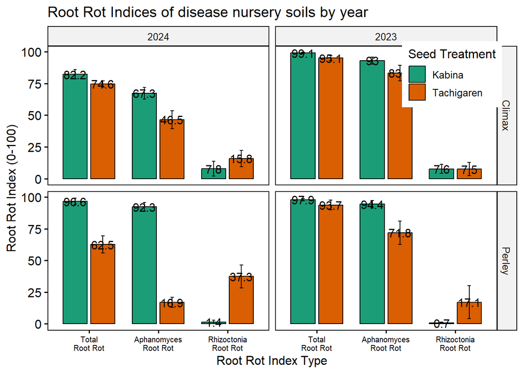

```r
ggbarplot(Assay_long,
          x = "RRI_Type",
          y = "Index_Value",
          fill = "Trmt",


          # slightly different than ggplot2
          facet.by = c("Soil", "Year"), nrow = 2,

          # BOTH 'add = "mean",' AND 'position = position_dodge(1)' NEED TO BE USED FOR BARPLOTS
          # This adds standard error bars
          add = 'mean_se',

          # this separates the columns, rather than being stacked
          position = position_dodge(0.8),



          # these control the data labels
          label = TRUE,
          lab.size = 4,
          lab.vjust = 0.5,
          lab.nb.digits = 1,

          # We can change these titles here, but not the legend title
          xlab = "Root Rot Index Type",
          ylab = "Root Rot Index (0-100)",
          title = "Root Rot Indices of disease nursery soils by year"

          ) +

   labs(fill = "Seed Treatment") +

  # This comes from the RColorBrewer Package
  scale_fill_brewer(palette = "Dark2") +


  theme(axis.text.x = element_text(size = 7.5),

        # You can place the legend anywhere within the plot using a vector
        legend.position = c(0.9,0.9))
```

## ggpubr boxplot and jitter

**Let’s try a different plot with ggpubr**

- We will use **ggboxplot()** from the ggpubr package
- I am also introducing **jitter** points and manually changing shapes or colors

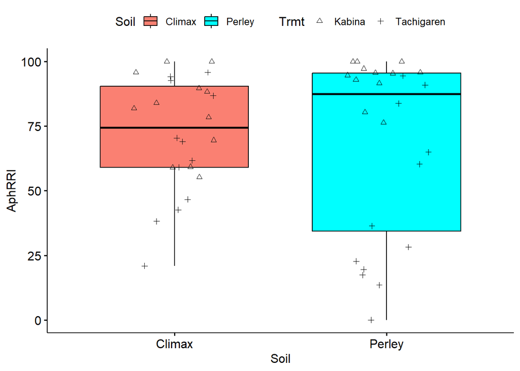

```r
ggboxplot(Assay,
          x = "Soil",
          y = "AphRRI",
          fill = "Soil",
          add = "jitter",

          # this is adding jitter points according to treatment
          # we could also assign the color
          add.params = list(shape = "Trmt"),
          ) +

# This manually changed the jitter shapes (shape = )
scale_shape_manual(values = c(2,3)) +

# This changed the boxplot (fill = ) color
scale_fill_manual(values = c("salmon", "cyan"))
```

**We can also view the distribution of the data using a violin plot**

## violin plot

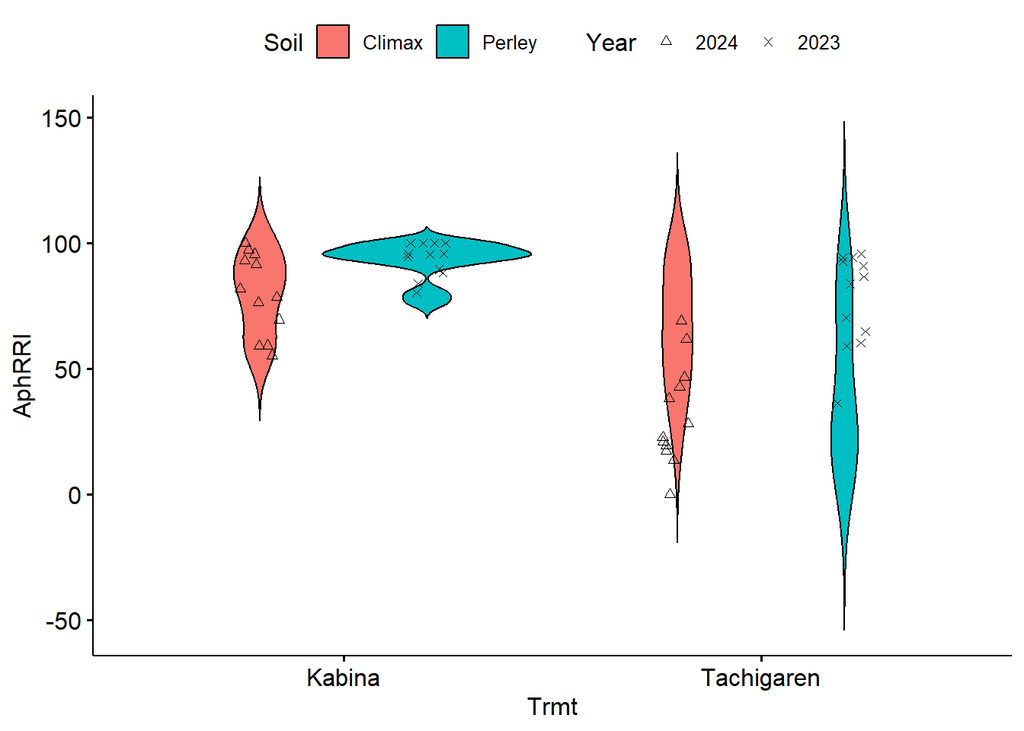

```r
ggviolin(Assay,
          x = "Trmt",
          add = 'jitter',
          fill = "Soil",
          y = "AphRRI",
          add.params = list(shape = "Year",
                            fill = "Soil")) +
  scale_shape_manual(values = c(2,4))
```

## ggpubr line graph

Now, let’s create line graphs using **ggline()** to display trends and patterns over a continuous variable, making them suitable for time series data or any data with a natural ordering.

The columns labelled c(‘DAP_6’, ‘DAP_14’, ‘DAP_21’, ‘DAP_28’) are Days After Planting (DAP).

**First, we need to create a new data.frame and use pivot_longer() to transpose these columns. We can also rename our values within our new column and make sure they are in the correct order**

```r
Assay_plants <- pivot_longer(Assay,
                             cols = c('DAP_6', 'DAP_14', 'DAP_21', 'DAP_28'),
                             names_to = "DAP",
                             values_to = "plants")

Assay_plants$DAP <- ordered(Assay_plants$DAP,
                            levels = c('DAP_6', 'DAP_14', 'DAP_21', 'DAP_28'),
                            labels = c('6','14','21','28'))
```

Now, we can use **ggline()** to create a line graph with DAP on the x axis.

- I will also introduce the **guides()** argument to customize labels in our legend and **rremove()** to remove specific components from a plot.

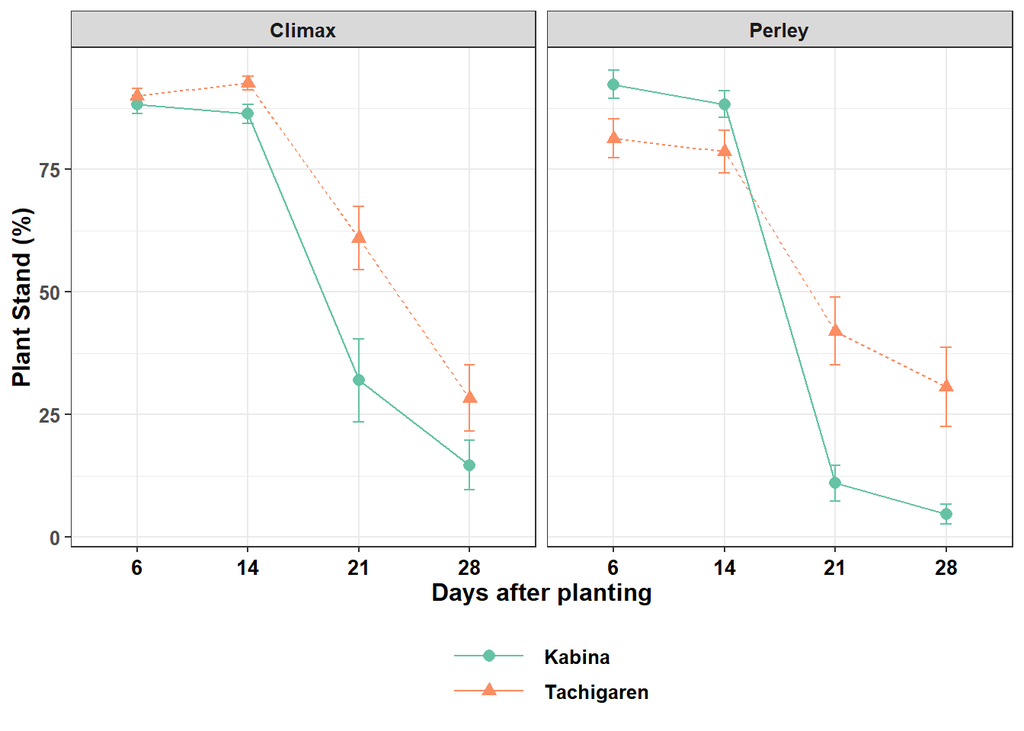

```r
ggline(Assay_plants,
       x = "DAP",
       y = "plants",
       group = "Trmt",
       color = 'Trmt',
       linetype = 'Trmt',
       shape = "Trmt",


       # without adding 'add = mean' or another variation, the line graph will not be logical
       add = c('mean_se'),

       facet.by = 'Soil',

       # creates both lines and points
       plot_type = 'b',

       # this changes the size of the points
       point.size = 1.2,


       ylab = "Plant Stand (%)",
       xlab = "Days after planting",


       # makes x axis as numeric (i.e., logical spacing between values)
       numeric.x.axis = TRUE

       ) +

  theme_bw() +

  theme(text = element_text(
                            # family = "Times New Roman",
                            # we can use the family argument once you install and load the 'extrafont' package
                            size = 12,
                            face = "bold",
                            color = "black"),
        axis.text.x = element_text(angle = 0,
                                   size = 10,
                                   color = "black",
                                   vjust = 0.5,
                                   hjust = 0.5),
        legend.position = "bottom",

        # This changes the width inside the legend, making them easier to distinguish
        legend.key.width = unit(1.5, "cm")) +

  # rremove can be used to remove a specific component from a plot
  rremove('legend.title') +

  # guides can be used to customize legends
  guides(color = guide_legend(nrow = 2)) +


  scale_color_brewer(palette = 'Set2')
```

## ggpubr scatter plot

We will now use **ggscatter()** to visualize the relationship between RhizRRI and AphRRI

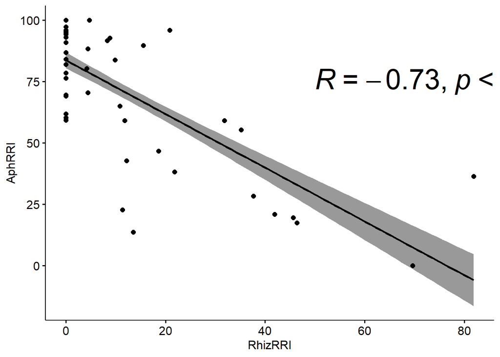

```r
ggscatter(Assay_plants,
          x= "RhizRRI",
          y = "AphRRI",

          # displays regression line
          add = "reg.line",

          # displays buffer around regression line representing confidence interval
          conf.int = TRUE,

          # displays correlation coefficient, size, and method
          cor.coef = TRUE,
          cor.coef.size = 10,
          cor.method = "pearson",

          # moves the location of the data displayed in the plot
          cor.coef.coord = c(50, 75)

          )
```

- We will need to use **stat_cor()** argument for displaying the coefficients for each treatment.
  - ggscatter will display both lines but will only display one coefficient.

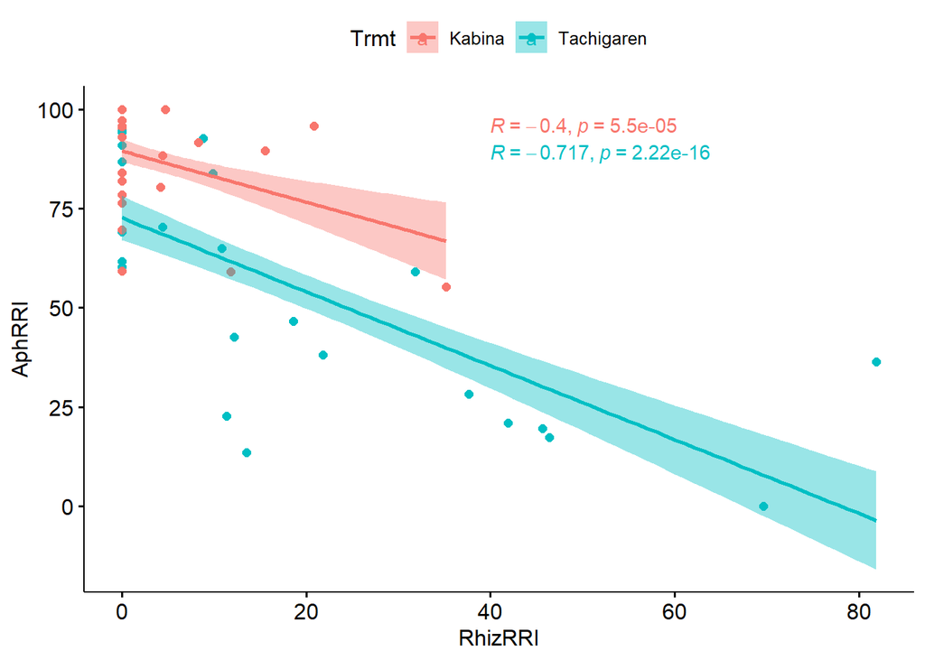

```r
ggscatter(Assay_plants,
          x= "RhizRRI",
          y = "AphRRI",

         # Displays regression lines and confidence interval for each factor signified by color
          color="Trmt",
          add = "reg.line",
          conf.int = TRUE,
          )+

  # extension of ggpubr to further customize correlation stats, here we are displaying the coefficients for each Trmt.
  stat_cor(aes(color = Trmt),
           method = "pearson",
           label.x = 40,
           digits = 3)
```

# Piping and Creating Tables

Tables are essential for presenting detailed data summaries and results, especially in research and data analysis.

the package **kableExtra** simplifies the creation of aesthetically pleasing and customizable tables, enhancing the presentation of summary statistics and other tabular data.

- kable() is a function from the knitr package, and it is primarily used for converting data frames into markdown or LaTeX tables.
  - It provides basic functionality for formatting tables, such as aligning columns, setting column names, and applying basic formatting options.
  - **kableExtra** is an extension package that builds upon kable() to provide additional customization options and formatting capabilities for tables with many arguments hidden in the background
    - this allows for more advanced customization of tables, making it suitable for creating publication-quality tables with complex formatting requirements.

```r
library(kableExtra)
# creates a table with auto formatting
kbl(Assay)
```

| Year | Soil | Trmt | Rep | DAP_6 | DAP_14 | DAP_21 | DAP_28 | TotalRRI | AphRRI | RhizRRI |
| --- | --- | --- | --- | --- | --- | --- | --- | --- | --- | --- |
| 2023 | Climax | Kabina | 1 | 96 | 84 | 32 | 0 | 100.00000 | 84.00000 | 0.000000 |
| 2023 | Climax | Kabina | 2 | 100 | 88 | 12 | 4 | 97.43590 | 89.64103 | 15.589744 |
| 2023 | Climax | Kabina | 3 | 88 | 84 | 20 | 0 | 100.00000 | 100.00000 | 0.000000 |
| 2023 | Climax | Kabina | 4 | 92 | 84 | 12 | 4 | 97.10145 | 88.27404 | 4.413702 |
| 2023 | Climax | Kabina | 5 | 88 | 80 | 4 | 0 | 100.00000 | 100.00000 | 4.761905 |
| 2023 | Climax | Kabina | 6 | 88 | 72 | 0 | 0 | 100.00000 | 95.83333 | 20.833333 |
| 2023 | Climax | Tachigaren | 1 | 100 | 100 | 52 | 20 | 88.00000 | 70.40000 | 4.400000 |
| 2023 | Climax | Tachigaren | 2 | 96 | 96 | 40 | 0 | 100.00000 | 95.83333 | 0.000000 |
| 2023 | Climax | Tachigaren | 3 | 88 | 88 | 52 | 0 | 100.00000 | 59.09091 | 31.818182 |
| 2023 | Climax | Tachigaren | 4 | 92 | 92 | 48 | 4 | 97.10145 | 92.68775 | 8.827405 |
| 2023 | Climax | Tachigaren | 5 | 88 | 92 | 72 | 12 | 91.30435 | 86.73913 | 0.000000 |
| 2023 | Climax | Tachigaren | 6 | 92 | 88 | 12 | 8 | 94.20290 | 94.20290 | 0.000000 |
| 2023 | Perley | Kabina | 1 | 72 | 76 | 0 | 0 | 100.00000 | 100.00000 | 0.000000 |
| 2023 | Perley | Kabina | 2 | 88 | 76 | 16 | 8 | 95.45455 | 95.45455 | 0.000000 |
| 2023 | Perley | Kabina | 3 | 108 | 92 | 4 | 0 | 100.00000 | 100.00000 | 0.000000 |
| 2023 | Perley | Kabina | 4 | 92 | 88 | 0 | 0 | 100.00000 | 95.83333 | 0.000000 |
| 2023 | Perley | Kabina | 5 | 88 | 96 | 32 | 4 | 97.22222 | 80.31401 | 4.227053 |
| 2023 | Perley | Kabina | 6 | 108 | 100 | 20 | 8 | 94.66667 | 94.66667 | 0.000000 |
| 2023 | Perley | Tachigaren | 1 | 72 | 64 | 12 | 0 | 100.00000 | 36.36364 | 81.818182 |
| 2023 | Perley | Tachigaren | 2 | 44 | 40 | 0 | 0 | 100.00000 | 90.90909 | 0.000000 |
| 2023 | Perley | Tachigaren | 3 | 92 | 92 | 60 | 12 | 92.75362 | 60.28986 | 0.000000 |
| 2023 | Perley | Tachigaren | 4 | 72 | 72 | 36 | 0 | 100.00000 | 94.44444 | 0.000000 |
| 2023 | Perley | Tachigaren | 5 | 80 | 80 | 20 | 8 | 93.65079 | 83.79282 | 9.857978 |
| 2023 | Perley | Tachigaren | 6 | 80 | 80 | 48 | 32 | 75.75758 | 64.93506 | 10.822511 |
| 2024 | Climax | Tachigaren | 1 | 96 | 96 | 80 | 60 | 65.27778 | 46.62698 | 18.650794 |
| 2024 | Climax | Tachigaren | 2 | 88 | 96 | 96 | 56 | 69.44444 | 61.72840 | 0.000000 |
| 2024 | Climax | Tachigaren | 3 | 80 | 88 | 60 | 40 | 79.16667 | 42.62821 | 12.179487 |
| 2024 | Climax | Tachigaren | 4 | 88 | 96 | 80 | 56 | 80.55556 | 69.04762 | 0.000000 |
| 2024 | Climax | Tachigaren | 5 | 88 | 96 | 60 | 40 | 76.38889 | 38.19444 | 21.825397 |
| 2024 | Climax | Tachigaren | 6 | 84 | 84 | 80 | 44 | 76.81159 | 20.94862 | 41.897233 |
| 2024 | Climax | Kabina | 1 | 80 | 92 | 72 | 32 | 81.15942 | 69.56522 | 0.000000 |
| 2024 | Climax | Kabina | 2 | 84 | 84 | 12 | 4 | 95.23810 | 78.43137 | 0.000000 |
| 2024 | Climax | Kabina | 3 | 88 | 88 | 80 | 52 | 66.66667 | 59.25926 | 0.000000 |
| 2024 | Climax | Kabina | 4 | 92 | 92 | 36 | 24 | 85.50725 | 55.32822 | 35.208866 |
| 2024 | Climax | Kabina | 5 | 88 | 96 | 80 | 32 | 81.94444 | 81.94444 | 0.000000 |
| 2024 | Climax | Kabina | 6 | 76 | 92 | 24 | 24 | 82.60870 | 59.00621 | 11.801242 |
| 2024 | Perley | Tachigaren | 1 | 92 | 92 | 28 | 24 | 84.72222 | 28.24074 | 37.654321 |
| 2024 | Perley | Tachigaren | 2 | 88 | 76 | 44 | 44 | 69.56522 | 17.39130 | 46.376812 |
| 2024 | Perley | Tachigaren | 3 | 92 | 88 | 56 | 48 | 69.56522 | 0.00000 | 69.565217 |
| 2024 | Perley | Tachigaren | 4 | 84 | 80 | 48 | 48 | 65.15152 | 19.54545 | 45.606061 |
| 2024 | Perley | Tachigaren | 5 | 88 | 88 | 72 | 72 | 45.45455 | 22.72727 | 11.363636 |
| 2024 | Perley | Tachigaren | 6 | 92 | 92 | 80 | 80 | 40.57971 | 13.52657 | 13.526570 |
| 2024 | Perley | Kabina | 1 | 92 | 88 | 0 | 0 | 100.00000 | 91.66667 | 8.333333 |
| 2024 | Perley | Kabina | 2 | 92 | 72 | 0 | 0 | 100.00000 | 95.65217 | 0.000000 |
| 2024 | Perley | Kabina | 3 | 88 | 88 | 0 | 0 | 100.00000 | 100.00000 | 0.000000 |
| 2024 | Perley | Kabina | 4 | 84 | 88 | 20 | 4 | 97.22222 | 92.99517 | 0.000000 |
| 2024 | Perley | Kabina | 5 | 96 | 96 | 8 | 8 | 97.22222 | 97.22222 | 0.000000 |
| 2024 | Perley | Kabina | 6 | 100 | 100 | 32 | 24 | 85.33333 | 76.35088 | 0.000000 |

**But to go any further, I need to introduce piping!**

- Piping simplifies the process of performing multiple operations on data by passing the output of one function directly as the input to another function.
  - The pipe operator **%>%** is used to chain operations together.
    - It takes the output of the expression on its left-hand side and feeds it as the first argument to the function on its right-hand side.
    - Piping makes code more readable and easier to understand, especially when performing multiple transformations on data.
    - It reduces the need for intermediate variables and allows for more compact code.
    - Piping is commonly used in data manipulation, data wrangling, and analysis workflows, where multiple operations are performed sequentially on datasets.
    - The keyboard shortcut is **Ctrl+Shft+M**

```r
kbl(Assay) %>%

  # uses the built-in bootstrap themes by default
  kable_classic(full_width = F, html_font = "Arial")
```

| Year | Soil | Trmt | Rep | DAP_6 | DAP_14 | DAP_21 | DAP_28 | TotalRRI | AphRRI | RhizRRI |
| --- | --- | --- | --- | --- | --- | --- | --- | --- | --- | --- |
| 2023 | Climax | Kabina | 1 | 96 | 84 | 32 | 0 | 100.00000 | 84.00000 | 0.000000 |
| 2023 | Climax | Kabina | 2 | 100 | 88 | 12 | 4 | 97.43590 | 89.64103 | 15.589744 |
| 2023 | Climax | Kabina | 3 | 88 | 84 | 20 | 0 | 100.00000 | 100.00000 | 0.000000 |
| 2023 | Climax | Kabina | 4 | 92 | 84 | 12 | 4 | 97.10145 | 88.27404 | 4.413702 |
| 2023 | Climax | Kabina | 5 | 88 | 80 | 4 | 0 | 100.00000 | 100.00000 | 4.761905 |
| 2023 | Climax | Kabina | 6 | 88 | 72 | 0 | 0 | 100.00000 | 95.83333 | 20.833333 |
| 2023 | Climax | Tachigaren | 1 | 100 | 100 | 52 | 20 | 88.00000 | 70.40000 | 4.400000 |
| 2023 | Climax | Tachigaren | 2 | 96 | 96 | 40 | 0 | 100.00000 | 95.83333 | 0.000000 |
| 2023 | Climax | Tachigaren | 3 | 88 | 88 | 52 | 0 | 100.00000 | 59.09091 | 31.818182 |
| 2023 | Climax | Tachigaren | 4 | 92 | 92 | 48 | 4 | 97.10145 | 92.68775 | 8.827405 |
| 2023 | Climax | Tachigaren | 5 | 88 | 92 | 72 | 12 | 91.30435 | 86.73913 | 0.000000 |
| 2023 | Climax | Tachigaren | 6 | 92 | 88 | 12 | 8 | 94.20290 | 94.20290 | 0.000000 |
| 2023 | Perley | Kabina | 1 | 72 | 76 | 0 | 0 | 100.00000 | 100.00000 | 0.000000 |
| 2023 | Perley | Kabina | 2 | 88 | 76 | 16 | 8 | 95.45455 | 95.45455 | 0.000000 |
| 2023 | Perley | Kabina | 3 | 108 | 92 | 4 | 0 | 100.00000 | 100.00000 | 0.000000 |
| 2023 | Perley | Kabina | 4 | 92 | 88 | 0 | 0 | 100.00000 | 95.83333 | 0.000000 |
| 2023 | Perley | Kabina | 5 | 88 | 96 | 32 | 4 | 97.22222 | 80.31401 | 4.227053 |
| 2023 | Perley | Kabina | 6 | 108 | 100 | 20 | 8 | 94.66667 | 94.66667 | 0.000000 |
| 2023 | Perley | Tachigaren | 1 | 72 | 64 | 12 | 0 | 100.00000 | 36.36364 | 81.818182 |
| 2023 | Perley | Tachigaren | 2 | 44 | 40 | 0 | 0 | 100.00000 | 90.90909 | 0.000000 |
| 2023 | Perley | Tachigaren | 3 | 92 | 92 | 60 | 12 | 92.75362 | 60.28986 | 0.000000 |
| 2023 | Perley | Tachigaren | 4 | 72 | 72 | 36 | 0 | 100.00000 | 94.44444 | 0.000000 |
| 2023 | Perley | Tachigaren | 5 | 80 | 80 | 20 | 8 | 93.65079 | 83.79282 | 9.857978 |
| 2023 | Perley | Tachigaren | 6 | 80 | 80 | 48 | 32 | 75.75758 | 64.93506 | 10.822511 |
| 2024 | Climax | Tachigaren | 1 | 96 | 96 | 80 | 60 | 65.27778 | 46.62698 | 18.650794 |
| 2024 | Climax | Tachigaren | 2 | 88 | 96 | 96 | 56 | 69.44444 | 61.72840 | 0.000000 |
| 2024 | Climax | Tachigaren | 3 | 80 | 88 | 60 | 40 | 79.16667 | 42.62821 | 12.179487 |
| 2024 | Climax | Tachigaren | 4 | 88 | 96 | 80 | 56 | 80.55556 | 69.04762 | 0.000000 |
| 2024 | Climax | Tachigaren | 5 | 88 | 96 | 60 | 40 | 76.38889 | 38.19444 | 21.825397 |
| 2024 | Climax | Tachigaren | 6 | 84 | 84 | 80 | 44 | 76.81159 | 20.94862 | 41.897233 |
| 2024 | Climax | Kabina | 1 | 80 | 92 | 72 | 32 | 81.15942 | 69.56522 | 0.000000 |
| 2024 | Climax | Kabina | 2 | 84 | 84 | 12 | 4 | 95.23810 | 78.43137 | 0.000000 |
| 2024 | Climax | Kabina | 3 | 88 | 88 | 80 | 52 | 66.66667 | 59.25926 | 0.000000 |
| 2024 | Climax | Kabina | 4 | 92 | 92 | 36 | 24 | 85.50725 | 55.32822 | 35.208866 |
| 2024 | Climax | Kabina | 5 | 88 | 96 | 80 | 32 | 81.94444 | 81.94444 | 0.000000 |
| 2024 | Climax | Kabina | 6 | 76 | 92 | 24 | 24 | 82.60870 | 59.00621 | 11.801242 |
| 2024 | Perley | Tachigaren | 1 | 92 | 92 | 28 | 24 | 84.72222 | 28.24074 | 37.654321 |
| 2024 | Perley | Tachigaren | 2 | 88 | 76 | 44 | 44 | 69.56522 | 17.39130 | 46.376812 |
| 2024 | Perley | Tachigaren | 3 | 92 | 88 | 56 | 48 | 69.56522 | 0.00000 | 69.565217 |
| 2024 | Perley | Tachigaren | 4 | 84 | 80 | 48 | 48 | 65.15152 | 19.54545 | 45.606061 |
| 2024 | Perley | Tachigaren | 5 | 88 | 88 | 72 | 72 | 45.45455 | 22.72727 | 11.363636 |
| 2024 | Perley | Tachigaren | 6 | 92 | 92 | 80 | 80 | 40.57971 | 13.52657 | 13.526570 |
| 2024 | Perley | Kabina | 1 | 92 | 88 | 0 | 0 | 100.00000 | 91.66667 | 8.333333 |
| 2024 | Perley | Kabina | 2 | 92 | 72 | 0 | 0 | 100.00000 | 95.65217 | 0.000000 |
| 2024 | Perley | Kabina | 3 | 88 | 88 | 0 | 0 | 100.00000 | 100.00000 | 0.000000 |
| 2024 | Perley | Kabina | 4 | 84 | 88 | 20 | 4 | 97.22222 | 92.99517 | 0.000000 |
| 2024 | Perley | Kabina | 5 | 96 | 96 | 8 | 8 | 97.22222 | 97.22222 | 0.000000 |
| 2024 | Perley | Kabina | 6 | 100 | 100 | 32 | 24 | 85.33333 | 76.35088 | 0.000000 |

We can also take our dataframe and pipe directly into the kbl() function and add some additional styling

```r
Assay %>%

# sets number of digits after the decimal point for all numbers
kbl(digits = 1) %>%


  kable_classic(full_width = F, html_font = "Arial") %>%

  # provides a clean approach to modify the style of HTML tables
  kable_styling(bootstrap_options = c("hover", "condensed", "responsive"))
```

| Year | Soil | Trmt | Rep | DAP_6 | DAP_14 | DAP_21 | DAP_28 | TotalRRI | AphRRI | RhizRRI |
| --- | --- | --- | --- | --- | --- | --- | --- | --- | --- | --- |
| 2023 | Climax | Kabina | 1 | 96 | 84 | 32 | 0 | 100.0 | 84.0 | 0.0 |
| 2023 | Climax | Kabina | 2 | 100 | 88 | 12 | 4 | 97.4 | 89.6 | 15.6 |
| 2023 | Climax | Kabina | 3 | 88 | 84 | 20 | 0 | 100.0 | 100.0 | 0.0 |
| 2023 | Climax | Kabina | 4 | 92 | 84 | 12 | 4 | 97.1 | 88.3 | 4.4 |
| 2023 | Climax | Kabina | 5 | 88 | 80 | 4 | 0 | 100.0 | 100.0 | 4.8 |
| 2023 | Climax | Kabina | 6 | 88 | 72 | 0 | 0 | 100.0 | 95.8 | 20.8 |
| 2023 | Climax | Tachigaren | 1 | 100 | 100 | 52 | 20 | 88.0 | 70.4 | 4.4 |
| 2023 | Climax | Tachigaren | 2 | 96 | 96 | 40 | 0 | 100.0 | 95.8 | 0.0 |
| 2023 | Climax | Tachigaren | 3 | 88 | 88 | 52 | 0 | 100.0 | 59.1 | 31.8 |
| 2023 | Climax | Tachigaren | 4 | 92 | 92 | 48 | 4 | 97.1 | 92.7 | 8.8 |
| 2023 | Climax | Tachigaren | 5 | 88 | 92 | 72 | 12 | 91.3 | 86.7 | 0.0 |
| 2023 | Climax | Tachigaren | 6 | 92 | 88 | 12 | 8 | 94.2 | 94.2 | 0.0 |
| 2023 | Perley | Kabina | 1 | 72 | 76 | 0 | 0 | 100.0 | 100.0 | 0.0 |
| 2023 | Perley | Kabina | 2 | 88 | 76 | 16 | 8 | 95.5 | 95.5 | 0.0 |
| 2023 | Perley | Kabina | 3 | 108 | 92 | 4 | 0 | 100.0 | 100.0 | 0.0 |
| 2023 | Perley | Kabina | 4 | 92 | 88 | 0 | 0 | 100.0 | 95.8 | 0.0 |
| 2023 | Perley | Kabina | 5 | 88 | 96 | 32 | 4 | 97.2 | 80.3 | 4.2 |
| 2023 | Perley | Kabina | 6 | 108 | 100 | 20 | 8 | 94.7 | 94.7 | 0.0 |
| 2023 | Perley | Tachigaren | 1 | 72 | 64 | 12 | 0 | 100.0 | 36.4 | 81.8 |
| 2023 | Perley | Tachigaren | 2 | 44 | 40 | 0 | 0 | 100.0 | 90.9 | 0.0 |
| 2023 | Perley | Tachigaren | 3 | 92 | 92 | 60 | 12 | 92.8 | 60.3 | 0.0 |
| 2023 | Perley | Tachigaren | 4 | 72 | 72 | 36 | 0 | 100.0 | 94.4 | 0.0 |
| 2023 | Perley | Tachigaren | 5 | 80 | 80 | 20 | 8 | 93.7 | 83.8 | 9.9 |
| 2023 | Perley | Tachigaren | 6 | 80 | 80 | 48 | 32 | 75.8 | 64.9 | 10.8 |
| 2024 | Climax | Tachigaren | 1 | 96 | 96 | 80 | 60 | 65.3 | 46.6 | 18.7 |
| 2024 | Climax | Tachigaren | 2 | 88 | 96 | 96 | 56 | 69.4 | 61.7 | 0.0 |
| 2024 | Climax | Tachigaren | 3 | 80 | 88 | 60 | 40 | 79.2 | 42.6 | 12.2 |
| 2024 | Climax | Tachigaren | 4 | 88 | 96 | 80 | 56 | 80.6 | 69.0 | 0.0 |
| 2024 | Climax | Tachigaren | 5 | 88 | 96 | 60 | 40 | 76.4 | 38.2 | 21.8 |
| 2024 | Climax | Tachigaren | 6 | 84 | 84 | 80 | 44 | 76.8 | 20.9 | 41.9 |
| 2024 | Climax | Kabina | 1 | 80 | 92 | 72 | 32 | 81.2 | 69.6 | 0.0 |
| 2024 | Climax | Kabina | 2 | 84 | 84 | 12 | 4 | 95.2 | 78.4 | 0.0 |
| 2024 | Climax | Kabina | 3 | 88 | 88 | 80 | 52 | 66.7 | 59.3 | 0.0 |
| 2024 | Climax | Kabina | 4 | 92 | 92 | 36 | 24 | 85.5 | 55.3 | 35.2 |
| 2024 | Climax | Kabina | 5 | 88 | 96 | 80 | 32 | 81.9 | 81.9 | 0.0 |
| 2024 | Climax | Kabina | 6 | 76 | 92 | 24 | 24 | 82.6 | 59.0 | 11.8 |
| 2024 | Perley | Tachigaren | 1 | 92 | 92 | 28 | 24 | 84.7 | 28.2 | 37.7 |
| 2024 | Perley | Tachigaren | 2 | 88 | 76 | 44 | 44 | 69.6 | 17.4 | 46.4 |
| 2024 | Perley | Tachigaren | 3 | 92 | 88 | 56 | 48 | 69.6 | 0.0 | 69.6 |
| 2024 | Perley | Tachigaren | 4 | 84 | 80 | 48 | 48 | 65.2 | 19.5 | 45.6 |
| 2024 | Perley | Tachigaren | 5 | 88 | 88 | 72 | 72 | 45.5 | 22.7 | 11.4 |
| 2024 | Perley | Tachigaren | 6 | 92 | 92 | 80 | 80 | 40.6 | 13.5 | 13.5 |
| 2024 | Perley | Kabina | 1 | 92 | 88 | 0 | 0 | 100.0 | 91.7 | 8.3 |
| 2024 | Perley | Kabina | 2 | 92 | 72 | 0 | 0 | 100.0 | 95.7 | 0.0 |
| 2024 | Perley | Kabina | 3 | 88 | 88 | 0 | 0 | 100.0 | 100.0 | 0.0 |
| 2024 | Perley | Kabina | 4 | 84 | 88 | 20 | 4 | 97.2 | 93.0 | 0.0 |
| 2024 | Perley | Kabina | 5 | 96 | 96 | 8 | 8 | 97.2 | 97.2 | 0.0 |
| 2024 | Perley | Kabina | 6 | 100 | 100 | 32 | 24 | 85.3 | 76.4 | 0.0 |

# Getting summary statistics

Summary statistics provide valuable insights into the characteristics and distributions of the data.

**rstatix** offers a convenient way to compute various summary statistics, such as means, medians, standard deviations, and correlations, streamlining the data analysis process.

```r
library(rstatix)
Assay %>%
get_summary_stats(type="common")
```

| variable | n | min | max | median | iqr | mean | sd | se | ci |
| --- | --- | --- | --- | --- | --- | --- | --- | --- | --- |
| DAP_6 | 48 | 44.00 | 108.000 | 88.000 | 8.000 | 88.000 | 10.139 | 1.464 | 2.944 |
| DAP_14 | 48 | 40.00 | 100.000 | 88.000 | 9.000 | 86.500 | 10.715 | 1.547 | 3.111 |
| DAP_21 | 48 | 0.00 | 96.000 | 32.000 | 48.000 | 36.500 | 28.698 | 4.142 | 8.333 |
| DAP_28 | 48 | 0.00 | 80.000 | 8.000 | 34.000 | 19.583 | 22.556 | 3.256 | 6.549 |
| TotalRRI | 48 | 40.58 | 100.000 | 94.435 | 19.792 | 87.713 | 14.716 | 2.124 | 4.273 |
| AphRRI | 48 | 0.00 | 100.000 | 81.129 | 36.413 | 70.661 | 28.435 | 4.104 | 8.257 |
| RhizRRI | 48 | 0.00 | 81.818 | 2.114 | 14.042 | 11.903 | 18.980 | 2.739 | 5.511 |

**However, this table won’t look to good once we knit our code, so let’s use what we learned with kableExtra to make it look better**

```r
Assay %>%

# common designates the type of summary statistics (many other options are available)
get_summary_stats(type="common") %>%


kbl(digits = 1) %>%
    kable_classic(full_width = F, html_font = "Arial") %>%
  kable_styling(bootstrap_options = c("hover", "condensed", "responsive"))
```

| variable | n | min | max | median | iqr | mean | sd | se | ci |
| --- | --- | --- | --- | --- | --- | --- | --- | --- | --- |
| DAP_6 | 48 | 44.0 | 108.0 | 88.0 | 8.0 | 88.0 | 10.1 | 1.5 | 2.9 |
| DAP_14 | 48 | 40.0 | 100.0 | 88.0 | 9.0 | 86.5 | 10.7 | 1.5 | 3.1 |
| DAP_21 | 48 | 0.0 | 96.0 | 32.0 | 48.0 | 36.5 | 28.7 | 4.1 | 8.3 |
| DAP_28 | 48 | 0.0 | 80.0 | 8.0 | 34.0 | 19.6 | 22.6 | 3.3 | 6.5 |
| TotalRRI | 48 | 40.6 | 100.0 | 94.4 | 19.8 | 87.7 | 14.7 | 2.1 | 4.3 |
| AphRRI | 48 | 0.0 | 100.0 | 81.1 | 36.4 | 70.7 | 28.4 | 4.1 | 8.3 |
| RhizRRI | 48 | 0.0 | 81.8 | 2.1 | 14.0 | 11.9 | 19.0 | 2.7 | 5.5 |

**Looks better right?**

Now what if we want to get summary stats just for a few variables?

```r
Assay %>%
get_summary_stats(c(TotalRRI, AphRRI, RhizRRI), type="common")  %>%

kbl(digits = 1) %>% kable_classic(full_width = F, html_font = "Arial")
```

| variable | n | min | max | median | iqr | mean | sd | se | ci |
| --- | --- | --- | --- | --- | --- | --- | --- | --- | --- |
| TotalRRI | 48 | 40.6 | 100.0 | 94.4 | 19.8 | 87.7 | 14.7 | 2.1 | 4.3 |
| AphRRI | 48 | 0.0 | 100.0 | 81.1 | 36.4 | 70.7 | 28.4 | 4.1 | 8.3 |
| RhizRRI | 48 | 0.0 | 81.8 | 2.1 | 14.0 | 11.9 | 19.0 | 2.7 | 5.5 |

But what if we want to get the summary statistics for each treatment, soil, or year?

# Introducing dplyr and statistical syntax

**dplyr** and tidyr provide a set of intuitive functions for manipulating data frames, making it ideal for tasks such as filtering, summarizing, mutating, and arranging data.

- dplyr and tidyr should already be loaded with tidyverse, but you can load it separately as well.
  - **group_by()** can be used to group data by one or more variables.
    - ungroup() removes grouping.
  - **filter()** can be used to subset your data based on specific criteria.
    - subset() can also be used to subset data (from base R)
  - **rename()** will rename columns.
  - **summarise()** is used to compute specific summary statistics within each group.
    - *I prefer using rstatix*
  - **mutate()** can create new variables based on existing ones or modify existing variables.
- Use **arrange()** to sort data based on one or more variables.
  - Continue to use the pipe operator %>% to chain together multiple dplyr operations in a single line, promoting readability and conciseness.
- **seperate()** turns a single character column into multiple columns

By mastering the functions provided by dplyr, you can streamline your data analysis workflow and gain greater control over your data processing tasks

Statistical operators in R are commonly used for performing various statistical calculations, hypothesis testing, and modeling. Here’s an overview of some common statistical operators and their syntax in R:

COMPARISON OPERATORS

- x == y # Equals
- x != y # Not equals
- x > y # Greater than
- x < y # Less than
- x >= y # Greater than or equal to
- x <= y # Less than or equal to
- a : z # Spans between start and end

LOGICAL OPERATORS

- x & y # AND
- x | y # OR
- !x # NOT

STATISTCAL FUNCTIONS

- mean(x) # Mean
- sd(x) # Standard deviation
- median(x) # Median
- cor(x, y) # Correlation coefficient
- quantile(x) # Quantiles

**Okay, now let’s group by Soil and get some summary statistics!**

```r
Assay %>%

  # converts to group
  group_by(Soil) %>%

# changed stats type to show only mean and standard deviation
get_summary_stats(TotalRRI, type= c("mean_sd"))  %>%


kbl(digits = 1) %>% kable_classic(full_width = F, html_font = "Arial")
```

| Soil | variable | n | mean | sd |
| --- | --- | --- | --- | --- |
| Climax | TotalRRI | 24 | 87.7 | 11.5 |
| Perley | TotalRRI | 24 | 87.7 | 17.6 |

**We can also group by both Soil AND Trmt and look at only the mean and standard error Root rot indices**

```r
Assay %>%
  group_by(Soil:Trmt) %>%
  get_summary_stats(c(TotalRRI, AphRRI, RhizRRI), type="mean_se")  %>%
  kbl(digits = 1) %>% kable_classic(full_width = F, html_font = "Arial")
```

| Soil:Trmt | variable | n | mean | se |
| --- | --- | --- | --- | --- |
| Climax:Kabina | TotalRRI | 12 | 90.6 | 3.1 |
| Climax:Kabina | AphRRI | 12 | 80.1 | 4.6 |
| Climax:Kabina | RhizRRI | 12 | 7.7 | 3.2 |
| Climax:Tachigaren | TotalRRI | 12 | 84.9 | 3.4 |
| Climax:Tachigaren | AphRRI | 12 | 64.8 | 7.1 |
| Climax:Tachigaren | RhizRRI | 12 | 11.6 | 4.1 |
| Perley:Kabina | TotalRRI | 12 | 97.3 | 1.2 |
| Perley:Kabina | AphRRI | 12 | 93.3 | 2.2 |
| Perley:Kabina | RhizRRI | 12 | 1.0 | 0.8 |
| Perley:Tachigaren | TotalRRI | 12 | 78.1 | 6.0 |
| Perley:Tachigaren | AphRRI | 12 | 44.3 | 9.5 |
| Perley:Tachigaren | RhizRRI | 12 | 27.2 | 8.2 |

**Now let’s use the filter() function to look at only 2024 data**

```r
Assay %>% filter(Year == "2024") %>%
  group_by(Soil:Trmt) %>%
  get_summary_stats(c(TotalRRI), type="mean_se")  %>%
  kbl(digits = 1) %>% kable_classic(full_width = F, html_font = "Arial")
```

| Soil:Trmt | variable | n | mean | se |
| --- | --- | --- | --- | --- |
| Climax:Kabina | TotalRRI | 6 | 82.2 | 3.8 |
| Climax:Tachigaren | TotalRRI | 6 | 74.6 | 2.4 |
| Perley:Kabina | TotalRRI | 6 | 96.6 | 2.3 |
| Perley:Tachigaren | TotalRRI | 6 | 62.5 | 6.8 |

**Let do only 2024 AND NOT the kabina treatment**

```r
Assay %>% dplyr::filter(Year == "2024" & Trmt != "Kabina") %>%
  group_by(Soil:Trmt) %>%
  get_summary_stats(c(TotalRRI), type="mean_se")  %>%
  kbl(digits = 1) %>% kable_classic(full_width = F, html_font = "Arial")
```

| Soil:Trmt | variable | n | mean | se |
| --- | --- | --- | --- | --- |
| Climax:Tachigaren | TotalRRI | 6 | 74.6 | 2.4 |
| Perley:Tachigaren | TotalRRI | 6 | 62.5 | 6.8 |

**OR we can remove the kabina treatment from just the 2023 trial**; this is done by the OR operator.

```r
Assay %>% filter(Year == "2024" | Trmt == "Tachigaren") %>%
  group_by(Soil:Trmt) %>%
  get_summary_stats(c(TotalRRI), type="mean_se")  %>%
  kbl(digits = 1) %>% kable_classic(full_width = F, html_font = "Arial")
```

| Soil:Trmt | variable | n | mean | se |
| --- | --- | --- | --- | --- |
| Climax:Kabina | TotalRRI | 6 | 82.2 | 3.8 |
| Climax:Tachigaren | TotalRRI | 12 | 84.9 | 3.4 |
| Perley:Kabina | TotalRRI | 6 | 96.6 | 2.3 |
| Perley:Tachigaren | TotalRRI | 12 | 78.1 | 6.0 |

**REMINDER: Rather than creating new strings for everything, you can also pipe this directly into summary statistics!**

**Now lets put it all together to create another table**

```r
Assay %>%
  group_by(Year:Soil:Trmt) %>%
  get_summary_stats(c(TotalRRI, AphRRI, RhizRRI), type="common") %>%

  dplyr::select(c('Year:Soil:Trmt', variable, mean)) %>%

  separate(col = 'Year:Soil:Trmt',
           into = c('Year', 'Soil', 'Trmt'),
           sep = ":") %>%

  pivot_wider(
    names_from = variable,
    values_from = c(mean)) %>%
  rename('Soil Location' = Soil,
         'Seed Treatment' = Trmt) %>%

  filter(Year == "2024") %>%

  kbl(digits = 1) %>%
    kable_classic(full_width = F, html_font = "Times New Roman") %>%
  kable_styling(bootstrap_options = c("hover", "condensed", "responsive"))
```

| Year | Soil Location | Seed Treatment | TotalRRI | AphRRI | RhizRRI |
| --- | --- | --- | --- | --- | --- |
| 2024 | Climax | Kabina | 82.2 | 67.3 | 7.8 |
| 2024 | Climax | Tachigaren | 74.6 | 46.5 | 15.8 |
| 2024 | Perley | Kabina | 96.6 | 92.3 | 1.4 |
| 2024 | Perley | Tachigaren | 62.5 | 16.9 | 37.3 |

**We can even go futher…just bare with me!**

```r
Assay %>%
  filter(Year == "2024") %>%
  group_by(Soil:Trmt) %>%
  get_summary_stats(c(TotalRRI, AphRRI, RhizRRI), type="common") %>%

  dplyr::select(c('Soil:Trmt', variable, mean, se)) %>%

  # mutates the variable 'mean' by using the function to round the number to one digit after the decimal
  mutate_at(vars(mean), funs(round(., 1))) %>%

  # mutates the variable standard error
  mutate_at(vars(se), funs(round(., 2))) %>%

  # takes the standard error column and pastes the plus/minus sign before the number and parenthesis around the everything
  mutate(se = paste0("(±", se, ")")) %>%

  # take the new standard error column and pastes it after the mean column
  mutate(mean = paste(mean, se, sep = " "))  %>%

  # drops se column
  dplyr::select(-se) %>%


  separate(col = 'Soil:Trmt',
           into = c('Soil', 'Trmt'),
           sep = ":") %>%

  pivot_wider(
    names_from = variable,
    values_from = c(mean)) %>%
  rename('Soil Location' = Soil,
         'Seed Treatment' = Trmt) %>%

  kbl() %>%
    kable_classic(full_width = F, html_font = "Times New Roman") %>%
  kable_styling(bootstrap_options = c("hover", "condensed", "responsive"))
```

| Soil Location | Seed Treatment | TotalRRI | AphRRI | RhizRRI |
| --- | --- | --- | --- | --- |
| Climax | Kabina | 82.2 (±3.76) | 67.3 (±4.55) | 7.8 (±5.8) |
| Climax | Tachigaren | 74.6 (±2.44) | 46.5 (±7.02) | 15.8 (±6.42) |
| Perley | Kabina | 96.6 (±2.33) | 92.3 (±3.42) | 1.4 (±1.39) |
| Perley | Tachigaren | 62.5 (±6.76) | 16.9 (±3.94) | 37.3 (±9) |

# Manipulating plots

## ordering by mean

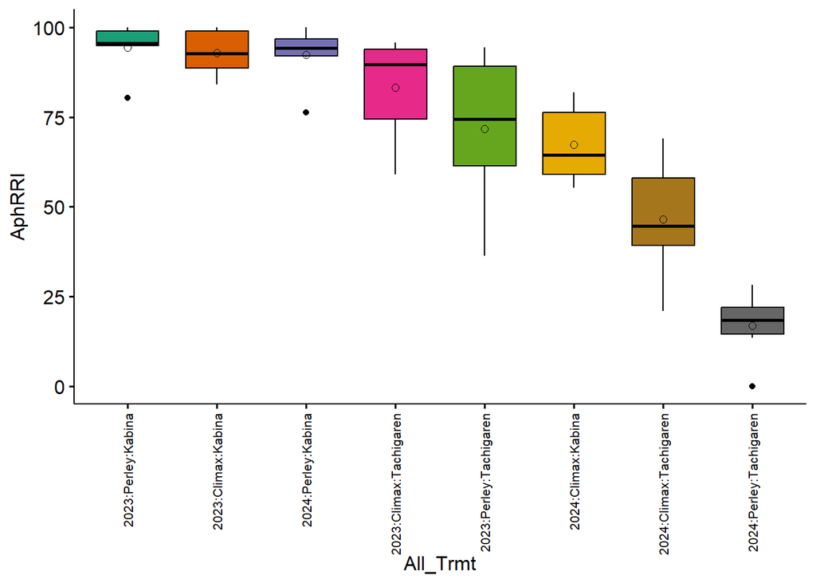

```r
Assay2 <- Assay

Assay2$All_Trmt <- paste(Assay2$Year,
                         Assay2$Soil,
                         Assay2$Trmt,
                        sep = ':')

Assay2$All_Trmt <- with(Assay2,

# This reorders our treatment column by descending means of AphRRI
                        reorder(All_Trmt, -AphRRI, mean))


ggboxplot(Assay2,
          x = "All_Trmt",
          y = "AphRRI",
          fill = "All_Trmt") +
  theme(legend.position = "none") +
  scale_fill_brewer(palette = "Dark2") +

  theme(axis.text.x = element_text(size = 8,
                                   angle = 90,
                                   hjust = 1,
                                   vjust = 0.5)) +

  stat_summary(fun = mean, geom = "point",

               # adds shape representing mean
               shape = 1, size = 2)
```

## dropping outliers

Here we are creating a boxplot to visualize any outliers

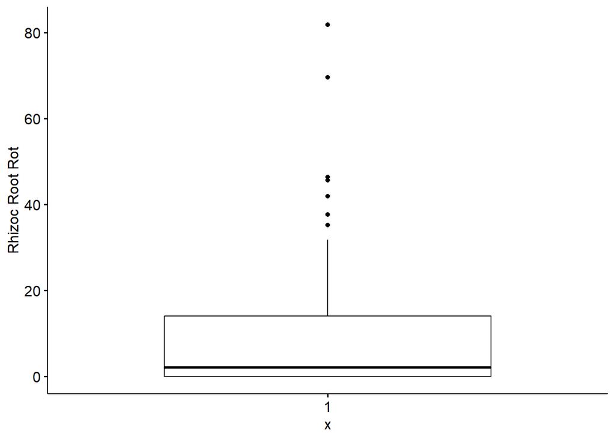

```r
ggboxplot(Assay,
          y = "RhizRRI",
          ylab = "Rhizoc Root Rot")
```

In ggplot2, an observation is defined as an outlier if it meets one of the following two requirements: The observation is 1.5 times the interquartile range less than the first quartile (Q1) The observation is 1.5 times the interquartile range greater than the third quartile (Q3).

Based on the figure, we can see that there are 7 dots representing outliers

```r
# This shows us the dimensions of our data fram (48 observations across 11 variables
dim(Assay)
```

```
## [1] 48 11
```

```r
# here we are defining the first and third quartiles
quartiles <- quantile(Assay$RhizRRI, probs = c(.25, .75), na.rm = FALSE)

# This is defining the interquartile range
IQR <- IQR(Assay$RhizRRI)

# This is setting our lower limit
lower <- quartiles[1] - 1.5*IQR

# This is setting our upper limit
upper <- quartiles[2] + 1.5*IQR

# Here we are keeping data that is greater than the lower limit and less than the upper limit
RhizRRI_No_outliers <- filter(Assay, Assay$RhizRRI > lower & Assay$RhizRRI < upper)

# Dimensions show that we now have only 41 observations
dim(RhizRRI_No_outliers)
```

```
## [1] 41 11
```

```r
RhizRRI_ONLY_outliers <- subset(Assay, Assay$RhizRRI <= lower | Assay$RhizRRI >= upper)
dim(RhizRRI_ONLY_outliers)
```

```
## [1]  7 11
```

# Analysis of Variance Models

```r
library(agricolae)

library(lme4)
# OR
library(lmerTest)
library(emmeans)

library(rcompanion)
```

## ANOVA (CRD) two-way factorial treatment structure

The two following models are identical

```r
# This signifies and ANOVA for Aph RRI in response to Soil and Trmt and the interaction between Soil and Trmt
# THIS IS THE SAME as below

# Using summary() allows use to see the output of the ANOVA model
# We also need to name the model so we can use it later on
model_1 <- aov(AphRRI ~ Soil + Trmt + Soil:Trmt, data = Assay)


summary(model_1)
```

```
##             Df Sum Sq Mean Sq F value   Pr(>F)
## Soil         1    158     158   0.315   0.5772
## Trmt         1  12389   12389  24.731 1.05e-05 ***
## Soil:Trmt    1   3414    3414   6.816   0.0123 *
## Residuals   44  22041     501
## ---
## Signif. codes:  0 '***' 0.001 '**' 0.01 '*' 0.05 '.' 0.1 ' ' 1
```

```r
model_2 <- aov(AphRRI ~ Soil*Trmt, data = Assay)
summary(model_2)
```

```
##             Df Sum Sq Mean Sq F value   Pr(>F)
## Soil         1    158     158   0.315   0.5772
## Trmt         1  12389   12389  24.731 1.05e-05 ***
## Soil:Trmt    1   3414    3414   6.816   0.0123 *
## Residuals   44  22041     501
## ---
## Signif. codes:  0 '***' 0.001 '**' 0.01 '*' 0.05 '.' 0.1 ' ' 1
```

## ANOVA (RCBD) two-way factorial treatment structure

```r
# This adds a blocking factor to the interaction between Soil and Trmt and main effects
# BE WARNED: This is not a mixed model! this is still a generalized linear model
model_3 <- aov(AphRRI ~ Rep + Soil*Trmt, data = Assay)


summary(model_3)
```

```
##             Df Sum Sq Mean Sq F value   Pr(>F)
## Rep          5   1447     289   0.548   0.7386
## Soil         1    158     158   0.299   0.5875
## Trmt         1  12389   12389  23.462 2.05e-05 ***
## Soil:Trmt    1   3414    3414   6.466   0.0151 *
## Residuals   39  20594     528
## ---
## Signif. codes:  0 '***' 0.001 '**' 0.01 '*' 0.05 '.' 0.1 ' ' 1
```

## LSD and HSD with agricolae

```r
library(agricolae)

model <- aov(AphRRI ~ Soil*Trmt + Rep, Assay)
summary(model)
```

```
##             Df Sum Sq Mean Sq F value   Pr(>F)
## Soil         1    158     158   0.299   0.5875
## Trmt         1  12389   12389  23.462 2.05e-05 ***
## Rep          5   1447     289   0.548   0.7386
## Soil:Trmt    1   3414    3414   6.466   0.0151 *
## Residuals   39  20594     528
## ---
## Signif. codes:  0 '***' 0.001 '**' 0.01 '*' 0.05 '.' 0.1 ' ' 1
```

```r
# Using LSD.test() performs Fisher's least significant difference
LSD.test(model,
         trt = 'Trmt',

         # alpha changes your significance level; default is 0.05)
         alpha = 0.1,
         console=TRUE)
```

```
##
## Study: model ~ "Trmt"
##
## LSD t Test for AphRRI
##
## Mean Square Error:  528.0459
##
## Trmt,  means and individual ( 90 %) CI
##
##              AphRRI      std  r      se      LCL      UCL      Min       Max
## Kabina     86.72662 13.98998 24 4.69062 78.82351 94.62972 55.32822 100.00000
## Tachigaren 54.59561 30.29713 24 4.69062 46.69250 62.49871  0.00000  95.83333
##                 Q25      Q50      Q75
## Kabina     79.84335 92.33092 96.18056
## Tachigaren 26.86237 59.69038 84.52939
##
## Alpha: 0.1 ; DF Error: 39
## Critical Value of t: 1.684875
##
## least Significant Difference: 11.17668
##
## Treatments with the same letter are not significantly different.
##
##              AphRRI groups
## Kabina     86.72662      a
## Tachigaren 54.59561      b
```

```r
LSD.test(model,
         trt = 'Soil',
         console=TRUE)
```

```
##
## Study: model ~ "Soil"
##
## LSD t Test for AphRRI
##
## Mean Square Error:  528.0459
##
## Soil,  means and individual ( 95 %) CI
##
##          AphRRI      std  r      se      LCL      UCL      Min Max      Q25
## Climax 72.47548 21.72071 24 4.69062 62.98780 81.96315 20.94862 100 59.06973
## Perley 68.84675 34.25815 24 4.69062 59.35907 78.33442  0.00000 100 34.33291
##             Q50      Q75
## Climax 74.41569 90.40271
## Perley 87.35095 95.50395
##
## Alpha: 0.05 ; DF Error: 39
## Critical Value of t: 2.022691
##
## least Significant Difference: 13.4176
##
## Treatments with the same letter are not significantly different.
##
##          AphRRI groups
## Climax 72.47548      a
## Perley 68.84675      a
```

```r
LSD.test(model,
         trt = c('Soil', 'Trmt'),
         console = TRUE)
```

```
##
## Study: model ~ c("Soil", "Trmt")
##
## LSD t Test for AphRRI
##
## Mean Square Error:  528.0459
##
## Soil:Trmt,  means and individual ( 95 %) CI
##
##                     AphRRI       std  r       se      LCL       UCL      Min
## Climax:Kabina     80.10693 16.019042 12 6.633538 66.68933  93.52452 55.32822
## Climax:Tachigaren 64.84402 24.551808 12 6.633538 51.42643  78.26162 20.94862
## Perley:Kabina     93.34631  7.550785 12 6.633538 79.92871 106.76390 76.35088
## Perley:Tachigaren 44.34719 32.974698 12 6.633538 30.92959  57.76478  0.00000
##                         Max      Q25      Q50      Q75
## Climax:Kabina     100.00000 66.98873 82.97222 91.18910
## Climax:Tachigaren  95.83333 45.62729 65.38801 88.22628
## Perley:Kabina     100.00000 92.66304 95.55336 97.91667
## Perley:Tachigaren  94.44444 19.00692 32.30219 69.64950
##
## Alpha: 0.05 ; DF Error: 39
## Critical Value of t: 2.022691
##
## least Significant Difference: 18.97535
##
## Treatments with the same letter are not significantly different.
##
##                     AphRRI groups
## Perley:Kabina     93.34631      a
## Climax:Kabina     80.10693     ab
## Climax:Tachigaren 64.84402      b
## Perley:Tachigaren 44.34719      c
```

## Checking assumptions and transformations

In linear regression analysis, it’s crucial to check the assumptions underlying the model to ensure that the results are valid and reliable. Two of the key assumptions that are often checked are the normality of the residuals and the homoscedasticity (constant variance) of the residuals. Here’s why it’s important to check these assumptions and how histograms and formal tests can be used:

- Normality of Residuals:
  - One of the assumptions in linear regression is that the residuals (the differences between observed and predicted values) are normally distributed.
  - The normality assumption is important because many statistical tests and confidence intervals associated with linear regression models rely on the normality of residuals.
  - Checking for normality can be done visually using histograms of the residuals. A histogram of residuals that closely resembles a bell-shaped curve suggests normality.
  - Formal tests for normality, such as the Shapiro-Wilk test or the Kolmogorov-Smirnov test, can also be performed to assess whether the residuals significantly deviate from a normal distribution.
  - histograms can also be used to visualize normality
- Homoscedasticity (Constant Variance) of Residuals:
  - Another assumption in linear regression is that the variance of the residuals is constant across all levels of the independent variables. This is known as homoscedasticity.
  - Homoscedasticity is important because unequal variances (heteroscedasticity) can lead to biased estimates of regression coefficients and incorrect standard errors, affecting the validity of statistical inference.
  - Visual inspection of residuals versus fitted values plot or residuals versus predictor variable plots can help detect patterns indicating non-constant variance. A horizontal band of points around zero suggests homoscedasticity.
  - Formal tests for homoscedasticity, such as the Breusch-Pagan test or the White test, can be conducted to statistically evaluate whether the variance of the residuals is constant across different levels of the independent variables.
- By checking these assumptions, particularly through the use of histograms for normality and diagnostic plots/tests for homoscedasticity, researchers can identify potential violations of the assumptions and take appropriate steps to address them. This may involve data transformation, using robust regression techniques, or considering alternative modeling approaches. Ensuring that the assumptions are met helps to maintain the reliability and validity of the regression analysis results.
- Levene’s test and the Breusch-Pagan test are both statistical tests used to assess the homogeneity of variance assumption in regression analysis. However, they differ in their approach and application:
  - Levene’s test is a non-parametric test used to assess the equality of variances across groups or treatments.
    - It compares the absolute deviations of individual observations from the group mean (or median) to evaluate whether these deviations are similar across groups.
    - Levene’s test does not assume normality of the data, making it robust against violations of normality assumptions.
    - It is often used in the context of analysis of variance (ANOVA) to check the homogeneity of variances assumption before proceeding with further analysis.
  - The Breusch-Pagan test is a parametric test used specifically in the context of regression analysis to assess the homoscedasticity assumption.
    - Homoscedasticity refers to the condition where the variance of the errors/residuals is constant across all levels of the independent variables.
    - The Breusch-Pagan test assesses whether the variance of the residuals in a regression model is dependent on the independent variables. If significant, it suggests heteroscedasticity, meaning the variance of the residuals is not constant across the range of values of the independent variables.
    - It is commonly used after running a regression model to check whether the assumptions of the linear regression model are met.

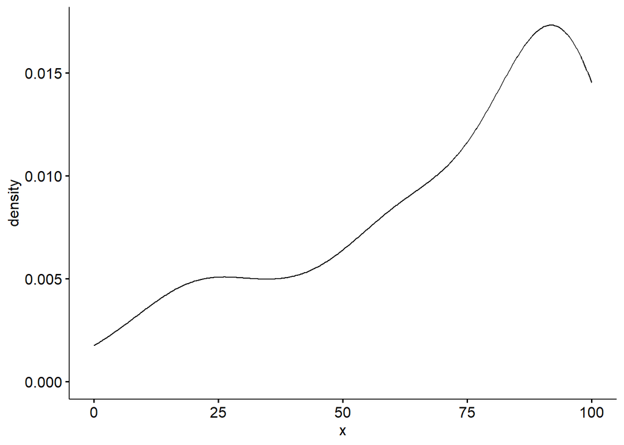

```r
library(car)
library(MASS)

# Creates density plot of given data values - similar to hist()
ggdensity(Assay$AphRRI)
```

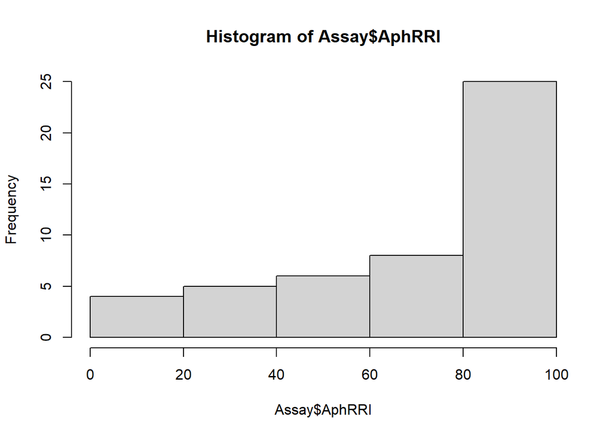

```r
# Creates histogram of given data values - similar to ggdensity()
hist(Assay$AphRRI)
```

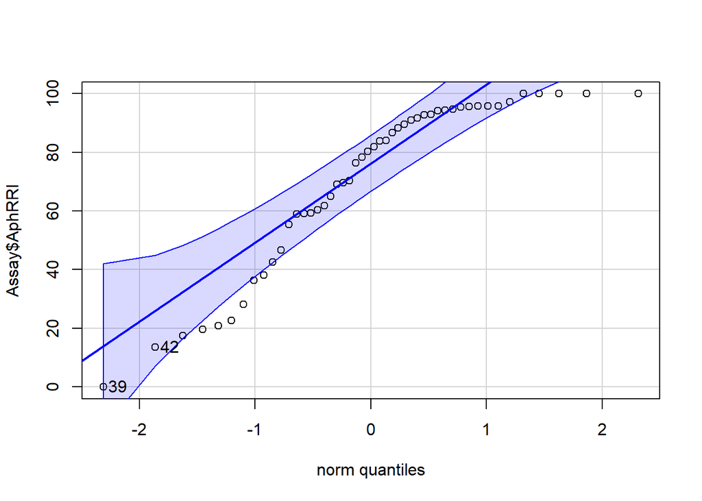

```
## [1] 39 42
```

```r
# Quantile-Comparison Plot of empirical quantiles of a variable
qqPlot(Assay$AphRRI)
```

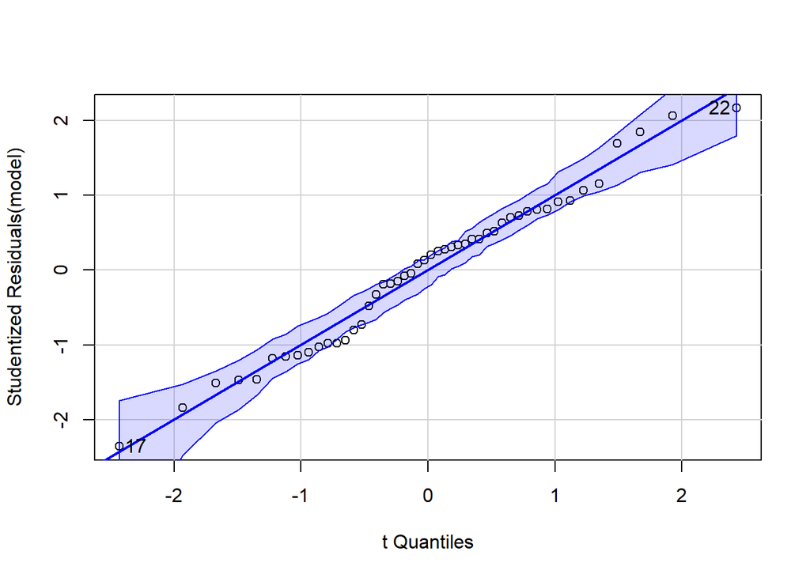

```
## [1] 17 22
```

```r
# Creates a linear model of Trmt and Soil main effects and interactions with of added blocking factor of the interaction between Replication and Year
model <- aov(AphRRI ~ Trmt*Soil + Rep:Year, data = Assay)

# Plots studentized residuals from a linear model
qqPlot(model)
```

```r
# Performs the Shapiro-Wilk test of normality
# null hypothesis is that the sample has been generated from normal distribution
shapiro.test(residuals(model))
```

```
##
##  Shapiro-Wilk normality test
##
## data:  residuals(model)
## W = 0.97748, p-value = 0.4785
```

```r
# Computes Levene's test for homogeneity of variance across the specified group(s).
leveneTest(lm(AphRRI ~ Soil*Trmt, data = Assay))
```

|  | Df | F value | Pr(>F) |
| --- | --- | --- | --- |
| group | 3 | 6.321692 | 0.0011658 |
|  | 44 | NA | NA |

```r
# computes score test for non-constant error variance
# another test for nonconstant variance called the Breusch-Pagan test
ncvTest(lm(AphRRI ~ Soil*Trmt, data = Assay))
```

```
## Non-constant Variance Score Test
## Variance formula: ~ fitted.values
## Chisquare = 14.50016, Df = 1, p = 0.00014015
```

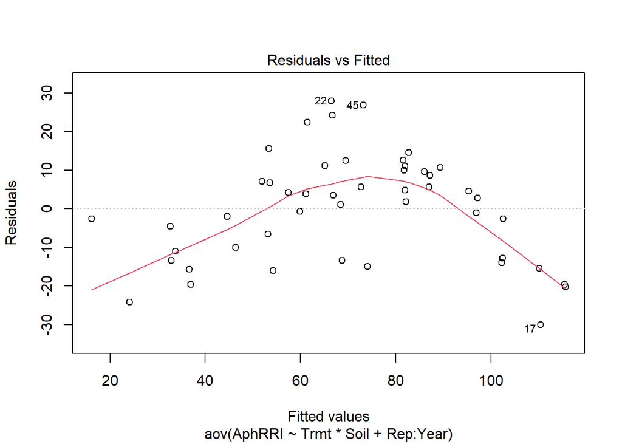

```r
# plots residuals vs fitted values
plot(model, 1)
```

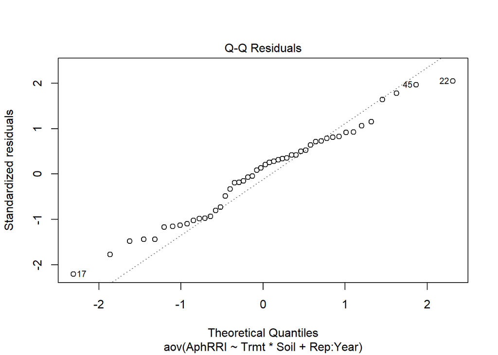

```r
# Creates qq-plot of standardized residuals
plot(model, 2)
```

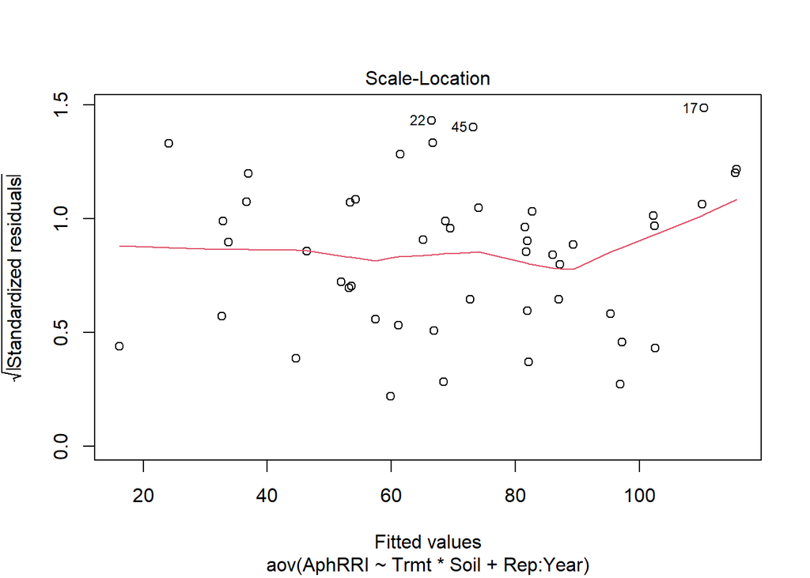

```r
# creates scale-location plot - similar to residuals vs fitted plot
plot(model, 3)
```

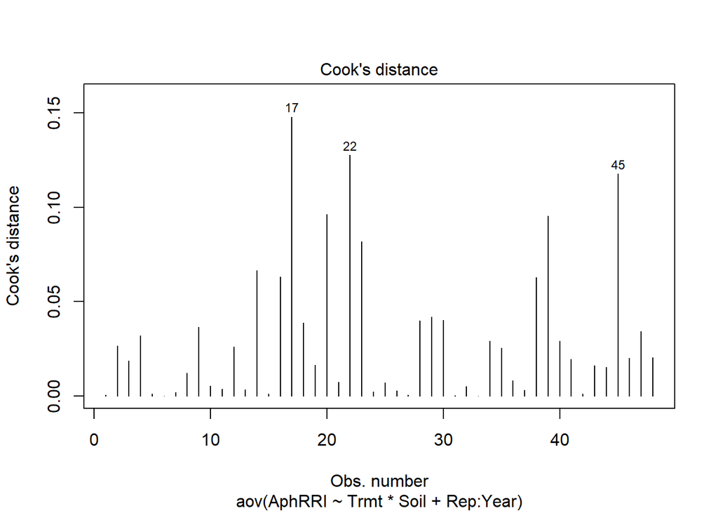

```r
# Plots Cook's distance, a measure of the influence of each individual data point (outliers)
plot(model, 4)
```

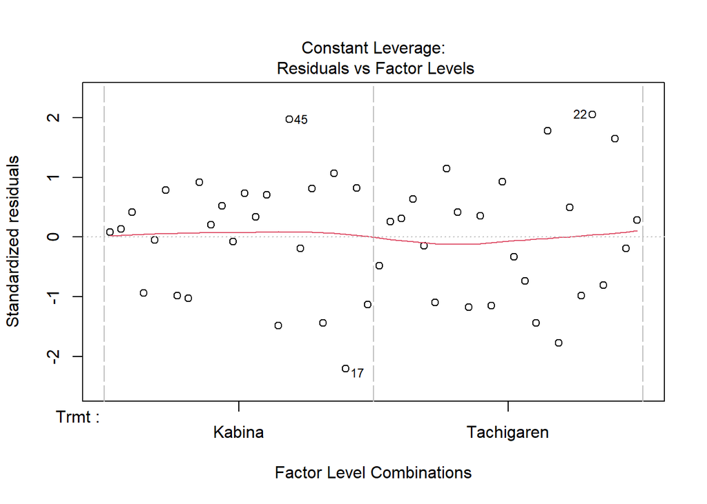

```r
# assesses the presence of influential observations or outliers within each level of a categorical predictor variable
plot(model, 5)
```

**Generally, lines in the model plots should be straight and/or fitted to be normal and homoscedastic**

lets try a power transformation and see if that resolves our violation of constant variance

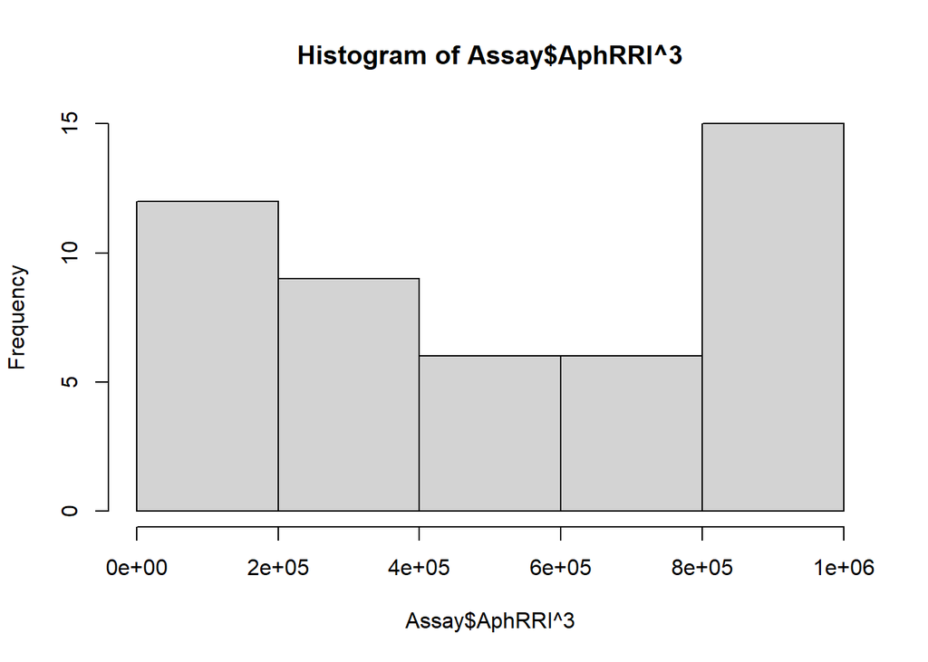

```r
model <- aov(AphRRI^3 ~ Trmt*Soil + Rep:Year, data = Assay)

hist(Assay$AphRRI^3)
```

```r
shapiro.test(residuals(model))
```

```
##
##  Shapiro-Wilk normality test
##
## data:  residuals(model)
## W = 0.98038, p-value = 0.5947
```

```r
leveneTest(lm(AphRRI^3 ~ Soil*Trmt, data = Assay))
```

|  | Df | F value | Pr(>F) |
| --- | --- | --- | --- |
| group | 3 | 1.16204 | 0.334984 |
|  | 44 | NA | NA |

```r
ncvTest(lm(AphRRI^3 ~ Soil*Trmt, data = Assay))
```

```
## Non-constant Variance Score Test
## Variance formula: ~ fitted.values
## Chisquare = 2.530762, Df = 1, p = 0.11165
```

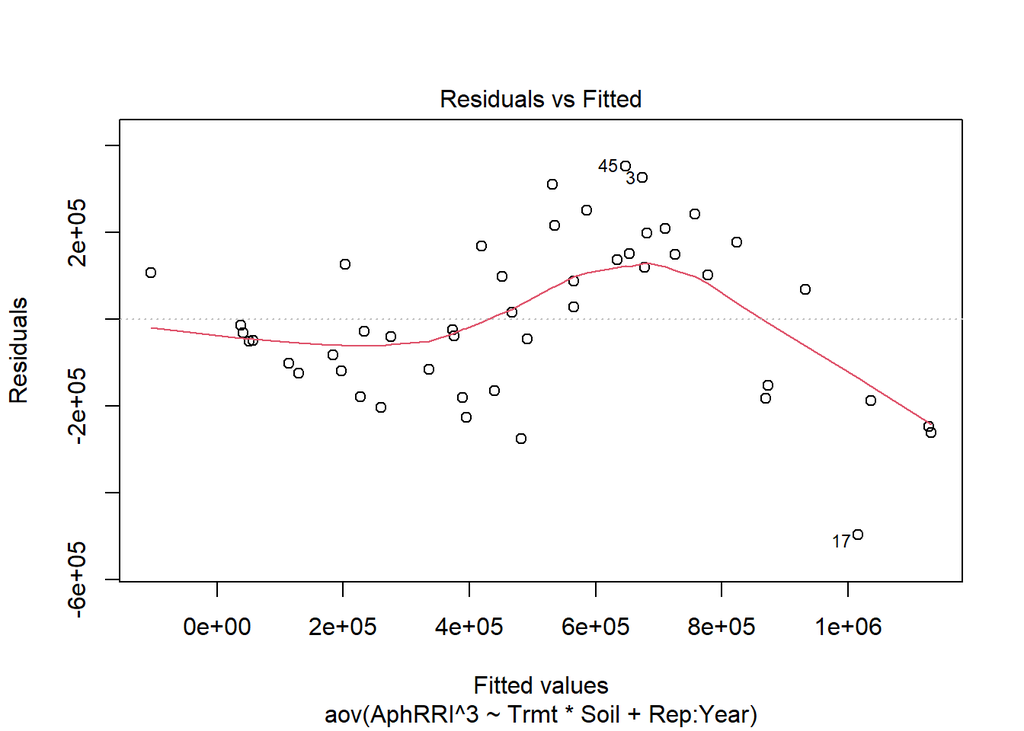

```r
plot(model, 1)
```

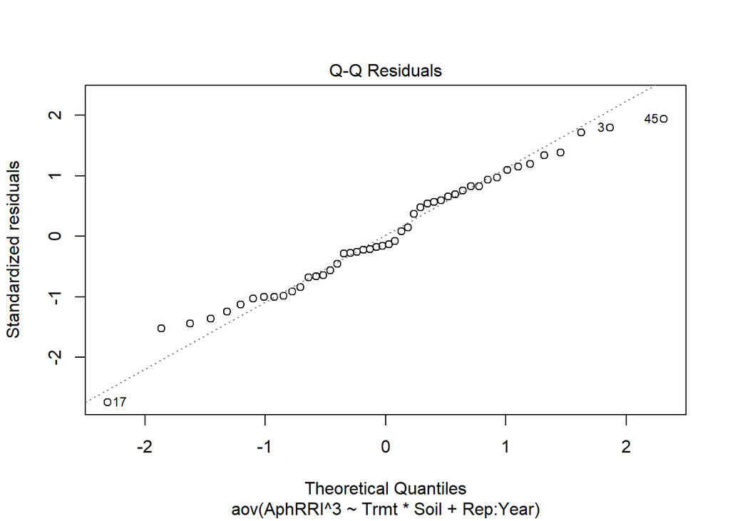

```r
plot(model, 2)
```

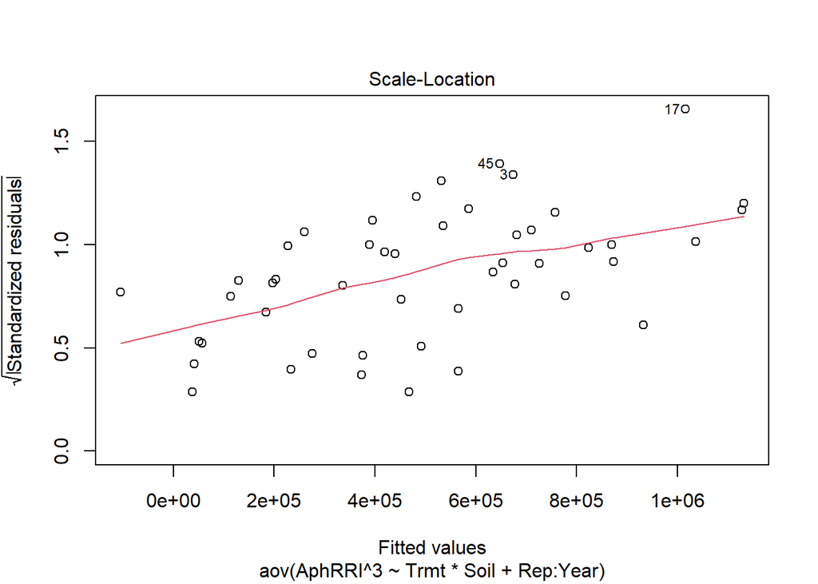

```r
plot(model, 3)
```

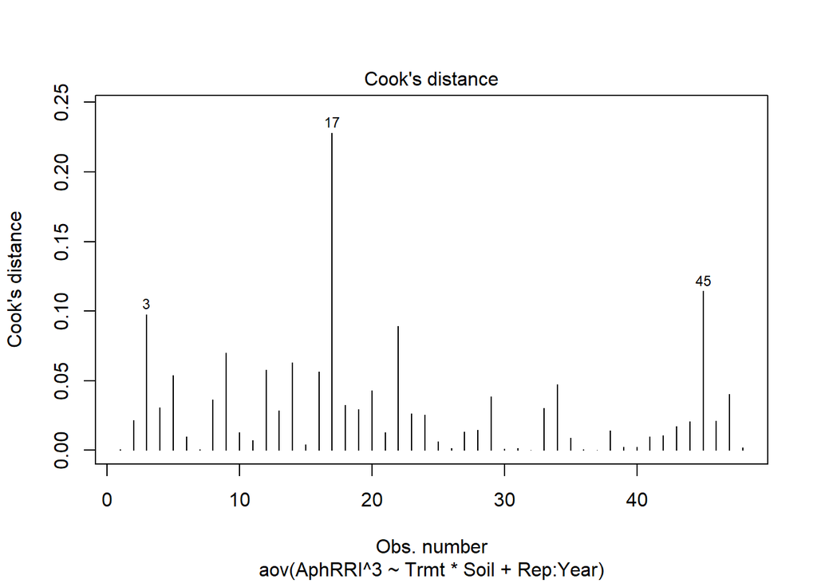

```r
plot(model, 4)
```

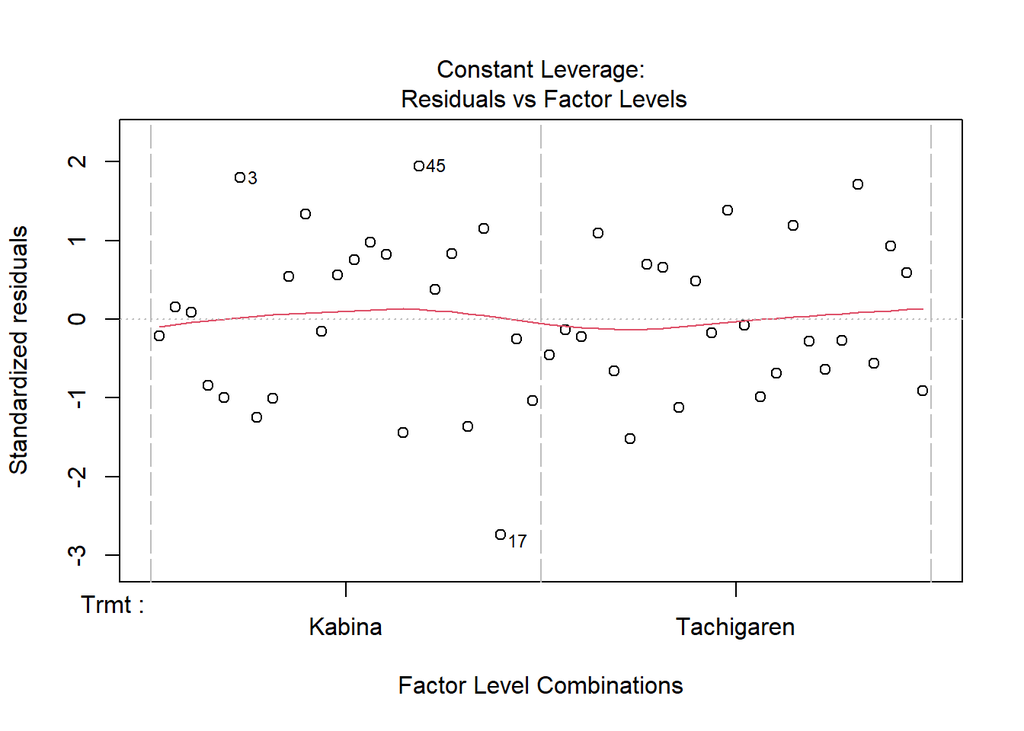

```r
plot(model, 5)
```

## Split-plot with agricolae

```r
model <- with(Assay, sp.plot(Rep:Year, Soil,Trmt,AphRRI))
```

```
##
## ANALYSIS SPLIT PLOT:  AphRRI
## Class level information
##
## Soil     :  Climax Perley
## Trmt     :  Kabina Tachigaren
## Rep:Year     :  1:2023 2:2023 3:2023 4:2023 5:2023 6:2023 1:2024 2:2024 3:2024 4:2024 5:2024 6:2024
##
## Number of observations:  48
##
## Analysis of Variance Table
##
## Response: AphRRI
##           Df  Sum Sq Mean Sq F value    Pr(>F)
## Rep:Year  11 13135.8  1194.2  3.1454  0.010658 *
## Soil       1   158.0   158.0  3.1431  0.103903
## Ea        11   553.0    50.3
## Trmt       1 12388.8 12388.8 32.6318 9.571e-06 ***
## Soil:Trmt  1  3414.4  3414.4  8.9934  0.006611 **
## Eb        22  8352.4   379.7
## ---
## Signif. codes:  0 '***' 0.001 '**' 0.01 '*' 0.05 '.' 0.1 ' ' 1
##
## cv(a) = 10 %, cv(b) = 27.6 %, Mean = 70.66111
```

```r
gla<-model$gl.a
glb<-model$gl.b
Ea<-model$Ea
Eb<-model$Eb


with(Assay, LSD.test(AphRRI,Soil, gla, Ea,
                     console=TRUE))
```

```
##
## Study: AphRRI ~ Soil
##
## LSD t Test for AphRRI
##
## Mean Square Error:  50.27234
##
## Soil,  means and individual ( 95 %) CI
##
##          AphRRI      std  r       se      LCL      UCL      Min Max      Q25
## Climax 72.47548 21.72071 24 1.447301 69.28999 75.66096 20.94862 100 59.06973
## Perley 68.84675 34.25815 24 1.447301 65.66126 72.03223  0.00000 100 34.33291
##             Q50      Q75
## Climax 74.41569 90.40271
## Perley 87.35095 95.50395
##
## Alpha: 0.05 ; DF Error: 11
## Critical Value of t: 2.200985
##
## least Significant Difference: 4.504961
##
## Treatments with the same letter are not significantly different.
##
##          AphRRI groups
## Climax 72.47548      a
## Perley 68.84675      a
```

```r
with(Assay, LSD.test(AphRRI,Trmt, glb, Eb,
                     console=TRUE))
```

```
##
## Study: AphRRI ~ Trmt
##
## LSD t Test for AphRRI
##
## Mean Square Error:  379.6551
##
## Trmt,  means and individual ( 95 %) CI
##
##              AphRRI      std  r       se      LCL      UCL      Min       Max
## Kabina     86.72662 13.98998 24 3.977306 78.47819 94.97504 55.32822 100.00000
## Tachigaren 54.59561 30.29713 24 3.977306 46.34718 62.84403  0.00000  95.83333
##                 Q25      Q50      Q75
## Kabina     79.84335 92.33092 96.18056
## Tachigaren 26.86237 59.69038 84.52939
##
## Alpha: 0.05 ; DF Error: 22
## Critical Value of t: 2.073873
##
## least Significant Difference: 11.66504
##
## Treatments with the same letter are not significantly different.
##
##              AphRRI groups
## Kabina     86.72662      a
## Tachigaren 54.59561      b
```

```r
with(Assay, LSD.test(AphRRI, Soil:Trmt, glb, Eb,
                     console=TRUE))
```

```
##
## Study: AphRRI ~ Soil:Trmt
##
## LSD t Test for AphRRI
##
## Mean Square Error:  379.6551
##
## Soil:Trmt,  means and individual ( 95 %) CI
##
##                     AphRRI       std  r      se      LCL       UCL      Min
## Climax:Kabina     80.10693 16.019042 12 5.62476 68.44189  91.77197 55.32822
## Climax:Tachigaren 64.84402 24.551808 12 5.62476 53.17898  76.50906 20.94862
## Perley:Kabina     93.34631  7.550785 12 5.62476 81.68127 105.01134 76.35088
## Perley:Tachigaren 44.34719 32.974698 12 5.62476 32.68215  56.01223  0.00000
##                         Max      Q25      Q50      Q75
## Climax:Kabina     100.00000 66.98873 82.97222 91.18910
## Climax:Tachigaren  95.83333 45.62729 65.38801 88.22628
## Perley:Kabina     100.00000 92.66304 95.55336 97.91667
## Perley:Tachigaren  94.44444 19.00692 32.30219 69.64950
##
## Alpha: 0.05 ; DF Error: 22
## Critical Value of t: 2.073873
##
## least Significant Difference: 16.49686
##
## Treatments with the same letter are not significantly different.
##
##                     AphRRI groups
## Perley:Kabina     93.34631      a
## Climax:Kabina     80.10693     ab
## Climax:Tachigaren 64.84402      b
## Perley:Tachigaren 44.34719      c
```

## Mixed-model with lmerTest and emmeans

```r
library(lmerTest)
library(emmeans)
```

```r
# 1 | x signifies random effect
# the mixed model needs to be named so we can bring it into the next step

model <- lmer(DAP_6 ~ Soil * Trmt + (1 | Year:Rep), data= Assay)
```

```
## boundary (singular) fit: see help('isSingular')
```

```r
anova(model) %>%  kbl() %>%
  kable_styling(bootstrap_options = c("hover", "condensed", "responsive"))
```

|  | Sum Sq | Mean Sq | NumDF | DenDF | F value | Pr(>F) |
| --- | --- | --- | --- | --- | --- | --- |
| Soil | 65.33333 | 65.33333 | 1 | 44 | 0.7143804 | 0.4025662 |
| Trmt | 261.33333 | 261.33333 | 1 | 44 | 2.8575215 | 0.0980212 |
| Soil:Trmt | 481.33333 | 481.33333 | 1 | 44 | 5.2630881 | 0.0266133 |

```r
# creates LSMEANS i.e., Estimated marginal means
fit <- emmeans(model, list(pairwise ~ Soil:Trmt), adjust = "none")

# adds compact letter display for EMMEANS
cld <- multcomp::cld(object = fit$emmeans,
                           Letters = letters)


kbl(cld) %>%
  kable_styling(bootstrap_options = c("hover", "condensed", "responsive"))
```

|  | Soil | Trmt | emmean | SE | df | lower.CL | upper.CL | .group |
| --- | --- | --- | --- | --- | --- | --- | --- | --- |
| 4 | Perley | Tachigaren | 81.33333 | 2.760654 | 44 | 75.76960 | 86.89707 | a |
| 1 | Climax | Kabina | 88.33333 | 2.760654 | 44 | 82.76960 | 93.89707 | ab |
| 3 | Climax | Tachigaren | 90.00000 | 2.760654 | 44 | 84.43627 | 95.56373 | ab |
| 2 | Perley | Kabina | 92.33333 | 2.760654 | 44 | 86.76960 | 97.89707 | b |

# Advanced tables for summary statistics

```r
model <- lmer(DAP_6 ~ Soil * Trmt + (1 | Rep)*(1 | Year), data= Assay)
```

```
## boundary (singular) fit: see help('isSingular')
```

```r
anova(model) %>%  kbl() %>%
  kable_styling(bootstrap_options = c("hover", "condensed", "responsive"))
```

|  | Sum Sq | Mean Sq | NumDF | DenDF | F value | Pr(>F) |
| --- | --- | --- | --- | --- | --- | --- |
| Soil | 65.33333 | 65.33333 | 1 | 44 | 0.7143804 | 0.4025662 |
| Trmt | 261.33333 | 261.33333 | 1 | 44 | 2.8575215 | 0.0980212 |
| Soil:Trmt | 481.33333 | 481.33333 | 1 | 44 | 5.2630881 | 0.0266133 |

```r
# Here we are grabbing the p value for the interactions (3rd line)
pval_DAP_6_int <- anova(model)$"Pr(>F)"[3]%>%  round(digits = 4)


fit <- emmeans(model, list(pairwise ~ Soil:Trmt), adjust = "none")
cld <- multcomp::cld(object = fit$emmeans,
                           Letters = letters)
kbl(cld) %>% kable_styling(bootstrap_options = c("hover", "condensed", "responsive"))
```

|  | Soil | Trmt | emmean | SE | df | lower.CL | upper.CL | .group |
| --- | --- | --- | --- | --- | --- | --- | --- | --- |
| 4 | Perley | Tachigaren | 81.33333 | 2.760654 | 12.25806 | 75.33240 | 87.33427 | a |
| 1 | Climax | Kabina | 88.33333 | 2.760654 | 12.25806 | 82.33240 | 94.33427 | ab |
| 3 | Climax | Tachigaren | 90.00000 | 2.760654 | 12.25806 | 83.99907 | 96.00093 | ab |
| 2 | Perley | Kabina | 92.33333 | 2.760654 | 12.25806 | 86.33240 | 98.33427 | b |

```r
cld_DAP_6_int <- cld %>%

  # this creates new table with only the variables, emmean, and letter group
  dplyr::select(c('Soil', 'Trmt', emmean, .group)) %>%

  # this rounds the emmean to a whole number
  mutate_at(vars(emmean), funs(round(., 0))) %>%

  # this creates a new column with both emmean and letter group
  mutate(emmean = paste(emmean, .group, sep = " "))  %>%

  # this drops the letter group column
  dplyr::select(-.group) %>%

  # this renames the emmean column
  rename('DAP_6' = emmean) %>%

  # this sorts our table so we can merge it with the next one.
  arrange(., Soil, Trmt)
model <- lmer(DAP_14 ~ Soil * Trmt + (1 | Rep)*(1 | Year), data= Assay)
anova(model) %>%  kbl() %>%
  kable_styling(bootstrap_options = c("hover", "condensed", "responsive"))
```

|  | Sum Sq | Mean Sq | NumDF | DenDF | F value | Pr(>F) |
| --- | --- | --- | --- | --- | --- | --- |
| Soil | 432.00000 | 432.00000 | 1 | 38 | 5.4237887 | 0.0252818 |
| Trmt | 33.33333 | 33.33333 | 1 | 38 | 0.4185022 | 0.5215741 |
| Soil:Trmt | 768.00000 | 768.00000 | 1 | 38 | 9.6422910 | 0.0035849 |

```r
pval_DAP_14_int <- anova(model)$"Pr(>F)"[3]%>%  round(digits = 4)

fit <- emmeans(model, list(pairwise ~ Soil:Trmt), adjust = "none")
cld <- multcomp::cld(object = fit$emmeans,
                           Letters = letters)
kbl(cld) %>%
  kable_styling(bootstrap_options = c("hover", "condensed", "responsive"))
```

|  | Soil | Trmt | emmean | SE | df | lower.CL | upper.CL | .group |
| --- | --- | --- | --- | --- | --- | --- | --- | --- |
| 4 | Perley | Tachigaren | 78.66667 | 3.905387 | 2.802348 | 65.72705 | 91.60629 | a |
| 1 | Climax | Kabina | 86.33333 | 3.905387 | 2.802348 | 73.39371 | 99.27295 | ab |
| 2 | Perley | Kabina | 88.33333 | 3.905387 | 2.802348 | 75.39371 | 101.27295 | ab |
| 3 | Climax | Tachigaren | 92.66667 | 3.905387 | 2.802348 | 79.72705 | 105.60629 | b |

```r
cld_DAP_14_int <- cld %>%
  dplyr::select(c('Soil', 'Trmt', emmean, .group)) %>%
  mutate_at(vars(emmean), funs(round(., 0))) %>%
  mutate(emmean = paste(emmean, .group, sep = " "))  %>%
  dplyr::select(-.group) %>%
  rename('DAP_14' = emmean) %>%
  arrange(., Soil, Trmt)
model <- lmer(DAP_21 ~ Soil * Trmt + (1 | Rep)*(1 | Year), data= Assay)
```

```
## boundary (singular) fit: see help('isSingular')
```

```r
anova(model) %>%  kbl() %>%
  kable_styling(bootstrap_options = c("hover", "condensed", "responsive"))
```

|  | Sum Sq | Mean Sq | NumDF | DenDF | F value | Pr(>F) |
| --- | --- | --- | --- | --- | --- | --- |
| Soil | 4800 | 4800 | 1 | 43 | 12.1908962 | 0.0011240 |
| Trmt | 10800 | 10800 | 1 | 43 | 27.4295165 | 0.0000046 |
| Soil:Trmt | 12 | 12 | 1 | 43 | 0.0304772 | 0.8622312 |

```r
pval_DAP_21_int <- anova(model)$"Pr(>F)"[3]%>%  round(digits = 4)

fit <- emmeans(model, list(pairwise ~ Soil:Trmt), adjust = "none")
cld <- multcomp::cld(object = fit$emmeans,
                           Letters = letters)
kbl(cld) %>%
  kable_styling(bootstrap_options = c("hover", "condensed", "responsive"))
```

|  | Soil | Trmt | emmean | SE | df | lower.CL | upper.CL | .group |
| --- | --- | --- | --- | --- | --- | --- | --- | --- |
| 2 | Perley | Kabina | 11 | 12.37146 | 1.418119 | -69.7624 | 91.7624 | a |
| 1 | Climax | Kabina | 32 | 12.37146 | 1.418119 | -48.7624 | 112.7624 | ab |
| 4 | Perley | Tachigaren | 42 | 12.37146 | 1.418119 | -38.7624 | 122.7624 | bc |
| 3 | Climax | Tachigaren | 61 | 12.37146 | 1.418119 | -19.7624 | 141.7624 | c |

```r
cld_DAP_21_int <- cld %>%
  dplyr::select(c('Soil', 'Trmt', emmean, .group)) %>%
  mutate_at(vars(emmean), funs(round(., 0))) %>%
  mutate(emmean = paste(emmean, .group, sep = " "))  %>%
  dplyr::select(-.group) %>%
  rename('DAP_21' = emmean) %>%
  arrange(., Soil, Trmt)
model <- lmer(DAP_28 ~ Soil * Trmt + (1 | Rep)*(1 | Year), data= Assay)
```

```
## boundary (singular) fit: see help('isSingular')
```

```r
anova(model) %>%  kbl() %>%
  kable_styling(bootstrap_options = c("hover", "condensed", "responsive"))
```

|  | Sum Sq | Mean Sq | NumDF | DenDF | F value | Pr(>F) |
| --- | --- | --- | --- | --- | --- | --- |
| Soil | 176.3333 | 176.3333 | 1 | 43.00001 | 0.8834819 | 0.3525002 |
| Trmt | 4720.3333 | 4720.3333 | 1 | 43.00001 | 23.6502585 | 0.0000158 |
| Soil:Trmt | 456.3333 | 456.3333 | 1 | 43.00001 | 2.2863642 | 0.1378306 |

```r
pval_DAP_28_int <- anova(model)$"Pr(>F)"[3]%>%  round(digits = 4)


fit <- emmeans(model, list(pairwise ~ Soil:Trmt), adjust = "none")
cld <- multcomp::cld(object = fit$emmeans,
                           Letters = letters)
kbl(cld) %>%
  kable_styling(bootstrap_options = c("hover", "condensed", "responsive"))
```

|  | Soil | Trmt | emmean | SE | df | lower.CL | upper.CL | .group |
| --- | --- | --- | --- | --- | --- | --- | --- | --- |
| 2 | Perley | Kabina | 4.666667 | 14.8431 | 1.123501 | -141.3528 | 150.6861 | a |
| 1 | Climax | Kabina | 14.666667 | 14.8431 | 1.123501 | -131.3528 | 160.6861 | ab |
| 3 | Climax | Tachigaren | 28.333333 | 14.8431 | 1.123501 | -117.6861 | 174.3528 | bc |
| 4 | Perley | Tachigaren | 30.666667 | 14.8431 | 1.123501 | -115.3528 | 176.6861 | c |

```r
cld_DAP_28_int <- cld %>%
  dplyr::select(c('Soil', 'Trmt', emmean, .group)) %>%
  mutate_at(vars(emmean), funs(round(., 0))) %>%
  mutate(emmean = paste(emmean, .group, sep = " "))  %>%
  dplyr::select(-.group) %>%
  rename('DAP_28' = emmean) %>%
  arrange(., Soil, Trmt)
```

```r
# this creates a row containing our p values
pval <- (c(" ", "p-value", pval_DAP_6_int, pval_DAP_14_int,
           pval_DAP_21_int, pval_DAP_28_int))
```

## emmeans, letter grouping, and pvalue

```r
Assay %>%
  group_by(Soil:Trmt) %>%
  get_summary_stats(c(DAP_6, DAP_14, DAP_21, DAP_28), type="common") %>%

  dplyr::select(c('Soil:Trmt', variable, mean, se)) %>%

  mutate_at(vars(mean), funs(round(., 1))) %>%
  mutate_at(vars(se), funs(round(., 2))) %>%
  mutate(se = paste0("(±", se, ")")) %>%
  mutate(mean = paste(mean, se, sep = " "))  %>%
  dplyr::select(-se) %>%

  separate(col = 'Soil:Trmt',
           into = c('Soil', 'Trmt'),
           sep = ":") %>%

  pivot_wider(
    names_from = variable,
    values_from = c(mean)) %>%
  rename('Soil Location' = Soil,
         'Seed Treatment' = Trmt) %>%
  rbind(., pval) %>%

  kbl() %>%
    kable_classic(full_width = F, html_font = "Times New Roman") %>%
  kable_styling(bootstrap_options = c("hover", "condensed", "responsive"))
```

| Soil Location | Seed Treatment | DAP_6 | DAP_14 | DAP_21 | DAP_28 |
| --- | --- | --- | --- | --- | --- |
| Climax | Kabina | 88.3 (±1.87) | 86.3 (±1.87) | 32 (±8.46) | 14.7 (±5.05) |
| Climax | Tachigaren | 90 (±1.59) | 92.7 (±1.38) | 61 (±6.52) | 28.3 (±6.74) |
| Perley | Kabina | 92.3 (±2.89) | 88.3 (±2.72) | 11 (±3.62) | 4.7 (±2.02) |
| Perley | Tachigaren | 81.3 (±4.01) | 78.7 (±4.33) | 42 (±6.92) | 30.7 (±8.1) |
|  | p-value | 0.0266 | 0.0036 | 0.8622 | 0.1378 |

With Compact Letter Display

```r
cld_DAP_6_int %>%
  dplyr::left_join(cld_DAP_14_int, by = c('Soil', 'Trmt')) %>%
  dplyr::left_join(cld_DAP_21_int, by = c('Soil', 'Trmt')) %>%
  dplyr::left_join(cld_DAP_28_int, by = c('Soil', 'Trmt')) %>%
  mutate(Soil = as.character(Soil)) %>%
  mutate(Trmt = as.character(Trmt)) %>%
rbind(., pval) %>%

 kbl() %>%
    kable_classic(full_width = F, html_font = "Times New Roman") %>%
  kable_styling(bootstrap_options = c("hover", "condensed", "responsive"))
```

| Soil | Trmt | DAP_6 | DAP_14 | DAP_21 | DAP_28 |
| --- | --- | --- | --- | --- | --- |
| Climax | Kabina | 88 ab | 86 ab | 32 ab | 15 ab |
| Climax | Tachigaren | 90 ab | 93 b | 61 c | 28 bc |
| Perley | Kabina | 92 b | 88 ab | 11 a | 5 a |
| Perley | Tachigaren | 81 a | 79 a | 42 bc | 31 c |
|  | p-value | 0.0266 | 0.0036 | 0.8622 | 0.1378 |